# Sports-Related Concussion Recovery: A Biostatistical Analysis

SCAT5 Severity Scaling, Hypothesis Testing, A/B Testing, and Predictive Modeling of Return-to-Play Outcomes

Biostatistics Project

August 31, 2026

# 1 Introduction

This report analyzes a cohort of **30,000 athlete concussion events** to (1) build a clinically-interpretable **SCAT5 severity scale**, (2) run a comprehensive battery of **hypothesis tests** (with corrections for multiple comparisons) on the drivers of concussion severity and recovery time, (3) run a formal **A/B test** comparing high-contact vs. low-contact sports on prolonged recovery, and (4) build and compare **machine learning models** predicting prolonged return-to-play (RTP) and severity class.

The **SCAT5** (Sport Concussion Assessment Tool, 5th Edition) score in this data is a neurocognitive/symptom composite where **higher values indicate better neurological function** (closer to a healthy baseline of ~90-100), and **lower values indicate more severe acute impairment**. This is confirmed by the data: `baseline_scat5` (pre-injury) averages ~97, `scat5_acute` (immediately post-injury) averages ~36, and `scat5_pre_rtp` (at clearance) averages ~80 — i.e., scores drop sharply at injury and partially recover by the time an athlete returns to play.

```r
df <- read.csv("athlete_concussion_enriched_30k.csv", stringsAsFactors = FALSE)

df <- df %>%
  mutate(
    injury_date = as.Date(injury_date, format = "%m/%d/%Y"),
    return_to_play_date = as.Date(return_to_play_date, format = "%m/%d/%Y"),
    sex = factor(sex, levels = c("F", "M")),
    team_level = factor(team_level, levels = c("Youth/High School", "Collegiate", "Elite/Pro")),
    sport = factor(sport),
    season = factor(season, levels = c("Spring","Summer","Fall","Winter")),
    injury_setting = factor(injury_setting),
    concussion_mechanism = factor(concussion_mechanism),
    loss_of_consciousness = factor(loss_of_consciousness, levels = c("No","Yes")),
    amnesia_present = factor(amnesia_present, levels = c("No","Yes")),
    imaging_ordered = factor(imaging_ordered, levels = c("No","Yes")),
    prolonged_rtp_f = factor(prolonged_rtp, levels = c(0,1), labels = c("Normal RTP","Prolonged RTP")),
    high_contact_f = factor(high_contact, levels = c(0,1), labels = c("Lower-Contact","High-Contact")),
    pct_of_baseline = round(scat5_acute / baseline_scat5 * 100, 1)
  )

n_athletes <- n_distinct(df$athlete_id)
kable(data.frame(
  Metric = c("Total concussion events", "Unique athletes", "Sports represented",
             "Training centers", "Date range"),
  Value = c(format(nrow(df), big.mark=","), format(n_athletes, big.mark=","),
            n_distinct(df$sport), n_distinct(df$training_center),
            paste(min(df$injury_date, na.rm=TRUE), "to", max(df$injury_date, na.rm=TRUE)))
), caption = "Dataset Overview")
```

Dataset Overview

| Metric | Value |
| --- | --- |
| Total concussion events | 30,000 |
| Unique athletes | 25,565 |
| Sports represented | 9 |
| Training centers | 8 |
| Date range | 2010-01-01 to 2026-01-09 |

No missing values were present in any of the 35 fields (verified during data cleaning), so no imputation was required.

# 2 Building the SCAT5 Severity Scale

Rather than use arbitrary cut points on the raw `scat5_acute` score, we anchor severity to **each athlete’s own healthy baseline** by computing:

$$\text{Percent of Baseline} =
\frac{\text{scat5\_acute}}{\text{baseline\_scat5}} \times
100$$

```r
df <- df %>%
  mutate(
    severity_scale_3 = case_when(
      pct_of_baseline < 35 ~ "Severe",
      pct_of_baseline < 55 ~ "Medium",
      TRUE ~ "Low"
    ),
    severity_scale_3 = factor(severity_scale_3, levels = c("Low","Medium","Severe"), ordered = TRUE),

    severity_scale_5 = case_when(
      pct_of_baseline < 25 ~ "Very Severe",
      pct_of_baseline < 35 ~ "Severe",
      pct_of_baseline < 45 ~ "Moderate",
      pct_of_baseline < 55 ~ "Mild",
      TRUE ~ "Minimal"
    ),
    severity_scale_5 = factor(severity_scale_5,
                               levels = c("Minimal","Mild","Moderate","Severe","Very Severe"),
                               ordered = TRUE)
  )

kable(df %>% count(severity_scale_3) %>% mutate(pct = percent(n/sum(n))),
      caption = "3-Level SCAT5 Severity Scale (Low = mildest injury, Severe = worst)")
```

3-Level SCAT5 Severity Scale (Low = mildest injury, Severe = worst)

| severity_scale_3 | n | pct |
| --- | --- | --- |
| Low | 2150 | 7.2% |
| Medium | 14748 | 49.2% |
| Severe | 13102 | 43.7% |

```r
kable(df %>% count(severity_scale_5) %>% mutate(pct = percent(n/sum(n))),
      caption = "5-Level SCAT5 Severity Scale")
```

5-Level SCAT5 Severity Scale

| severity_scale_5 | n | pct |
| --- | --- | --- |
| Minimal | 2150 | 7.17% |
| Mild | 5378 | 17.93% |
| Moderate | 9370 | 31.23% |
| Severe | 8022 | 26.74% |
| Very Severe | 5080 | 16.93% |

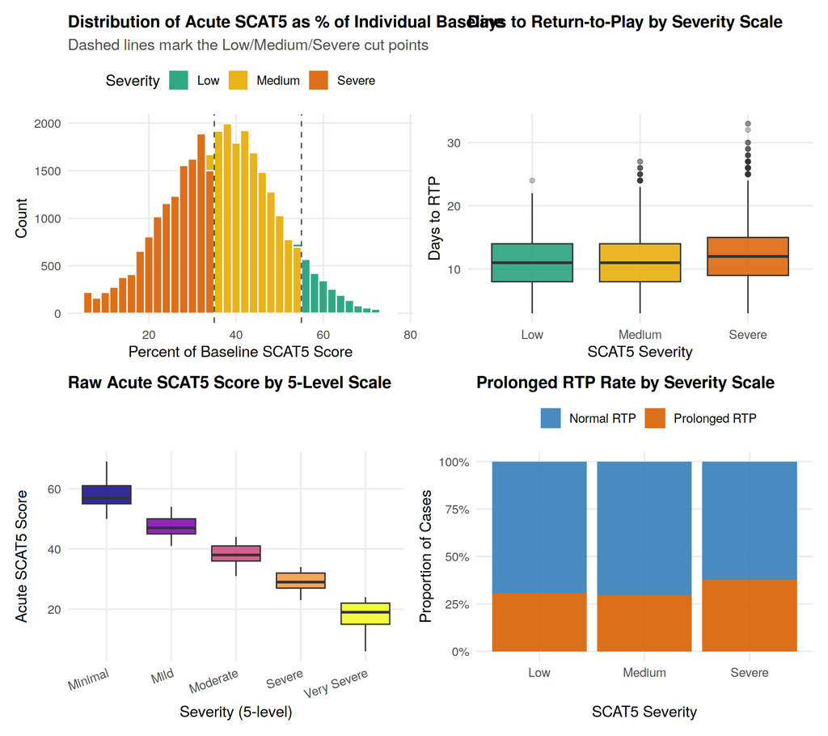

```r
p1 <- ggplot(df, aes(x = pct_of_baseline, fill = severity_scale_3)) +
  geom_histogram(binwidth = 2, color = "white", alpha = 0.9) +
  geom_vline(xintercept = c(35, 55), linetype = "dashed", color = "grey30") +
  scale_fill_manual(values = c("Low" = "#1b9e77", "Medium" = "#e6ab02", "Severe" = "#d95f02")) +
  labs(title = "Distribution of Acute SCAT5 as % of Individual Baseline",
       subtitle = "Dashed lines mark the Low/Medium/Severe cut points",
       x = "Percent of Baseline SCAT5 Score", y = "Count", fill = "Severity") +
  theme(legend.position = "top")

p2 <- ggplot(df, aes(x = severity_scale_3, y = days_to_rtp, fill = severity_scale_3)) +
  geom_boxplot(alpha = 0.85, outlier.alpha = 0.3) +
  scale_fill_manual(values = c("Low" = "#1b9e77", "Medium" = "#e6ab02", "Severe" = "#d95f02")) +
  labs(title = "Days to Return-to-Play by Severity Scale",
       x = "SCAT5 Severity", y = "Days to RTP") +
  theme(legend.position = "none")

p3 <- ggplot(df, aes(x = severity_scale_5, y = scat5_acute, fill = severity_scale_5)) +
  geom_boxplot(alpha = 0.85, outlier.alpha = 0.3) +
  scale_fill_viridis_d(option = "plasma") +
  labs(title = "Raw Acute SCAT5 Score by 5-Level Scale",
       x = "Severity (5-level)", y = "Acute SCAT5 Score") +
  theme(legend.position = "none", axis.text.x = element_text(angle = 20, hjust = 1))

p4 <- df %>%
  count(severity_scale_3, prolonged_rtp_f) %>%
  group_by(severity_scale_3) %>%
  mutate(pct = n/sum(n)) %>%
  ggplot(aes(x = severity_scale_3, y = pct, fill = prolonged_rtp_f)) +
  geom_col(position = "stack", alpha = 0.9) +
  scale_y_continuous(labels = percent) +
  scale_fill_manual(values = c("Normal RTP" = "#377eb8", "Prolonged RTP" = "#d95f02")) +
  labs(title = "Prolonged RTP Rate by Severity Scale", x = "SCAT5 Severity",
       y = "Proportion of Cases", fill = NULL) +
  theme(legend.position = "top")

(p1 + p2) / (p3 + p4)
```

# 3 Exploratory Data Analysis

## 3.1 Univariate Distributions

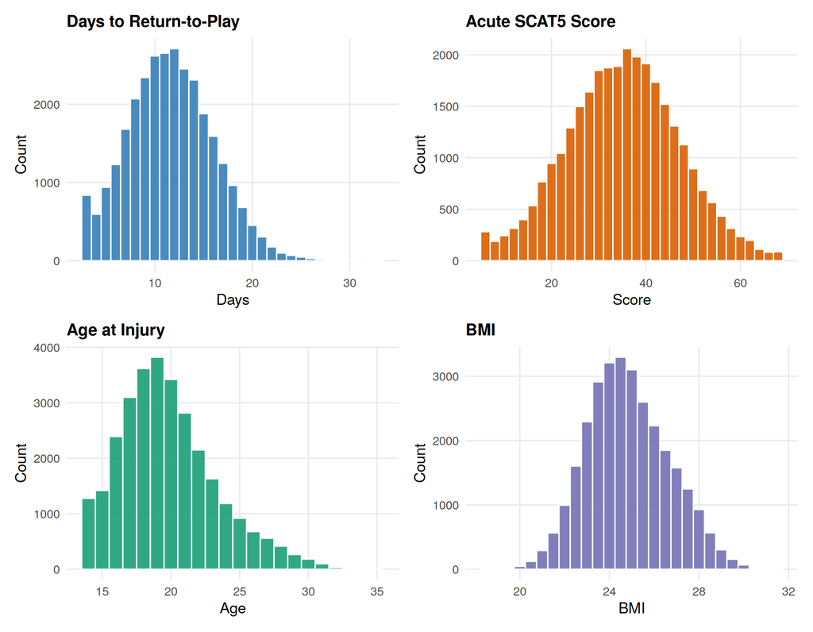

```r
p1 <- ggplot(df, aes(x = days_to_rtp)) +
  geom_histogram(binwidth = 1, fill = "#377eb8", color = "white", alpha = 0.9) +
  labs(title = "Days to Return-to-Play", x = "Days", y = "Count")

p2 <- ggplot(df, aes(x = scat5_acute)) +
  geom_histogram(binwidth = 2, fill = "#d95f02", color = "white", alpha = 0.9) +
  labs(title = "Acute SCAT5 Score", x = "Score", y = "Count")

p3 <- ggplot(df, aes(x = age_at_injury)) +
  geom_histogram(binwidth = 1, fill = "#1b9e77", color = "white", alpha = 0.9) +
  labs(title = "Age at Injury", x = "Age", y = "Count")

p4 <- ggplot(df, aes(x = bmi)) +
  geom_histogram(binwidth = 0.5, fill = "#7570b3", color = "white", alpha = 0.9) +
  labs(title = "BMI", x = "BMI", y = "Count")

(p1 + p2) / (p3 + p4)
```

## 3.2 Recovery and Severity by Sport, Sex, and Level

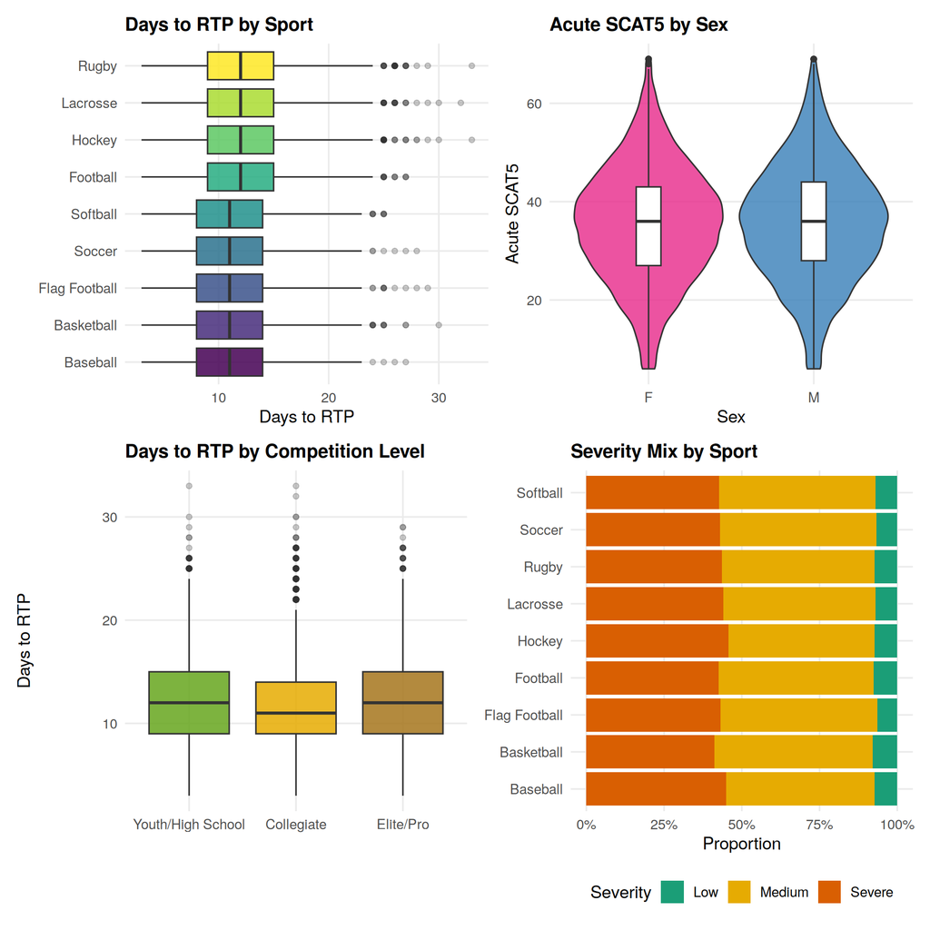

```r
p1 <- df %>%
  mutate(sport = fct_reorder(sport, days_to_rtp, .fun = median)) %>%
  ggplot(aes(x = sport, y = days_to_rtp, fill = sport)) +
  geom_boxplot(alpha = 0.85, outlier.alpha = 0.25) +
  scale_fill_viridis_d() +
  coord_flip() +
  labs(title = "Days to RTP by Sport", x = NULL, y = "Days to RTP") +
  theme(legend.position = "none")

p2 <- ggplot(df, aes(x = sex, y = scat5_acute, fill = sex)) +
  geom_violin(alpha = 0.8) +
  geom_boxplot(width = 0.15, fill = "white", outlier.alpha = 0.2) +
  scale_fill_manual(values = c("F" = "#e7298a", "M" = "#377eb8")) +
  labs(title = "Acute SCAT5 by Sex", x = "Sex", y = "Acute SCAT5") +
  theme(legend.position = "none")

p3 <- ggplot(df, aes(x = team_level, y = days_to_rtp, fill = team_level)) +
  geom_boxplot(alpha = 0.85, outlier.alpha = 0.25) +
  scale_fill_manual(values = c("Youth/High School" = "#66a61e", "Collegiate" = "#e6ab02", "Elite/Pro" = "#a6761d")) +
  labs(title = "Days to RTP by Competition Level", x = NULL, y = "Days to RTP") +
  theme(legend.position = "none")

p4 <- df %>%
  count(sport, severity_scale_3) %>%
  group_by(sport) %>%
  mutate(pct = n / sum(n)) %>%
  ggplot(aes(x = fct_reorder(sport, pct * (severity_scale_3=="Severe")), y = pct, fill = severity_scale_3)) +
  geom_col(position = "stack") +
  coord_flip() +
  scale_y_continuous(labels = percent) +
  scale_fill_manual(values = c("Low" = "#1b9e77", "Medium" = "#e6ab02", "Severe" = "#d95f02")) +
  labs(title = "Severity Mix by Sport", x = NULL, y = "Proportion", fill = "Severity") +
  theme(legend.position = "bottom")

(p1 + p2) / (p3 + p4)
```

## 3.3 Correlation Structure

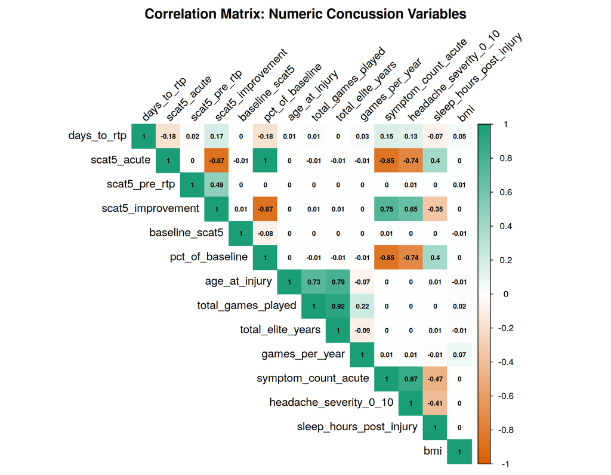

```r
num_vars <- df %>%
  dplyr::select(days_to_rtp, scat5_acute, scat5_pre_rtp, scat5_improvement, baseline_scat5,
                 pct_of_baseline, age_at_injury, total_games_played, total_elite_years,
                 games_per_year, symptom_count_acute, headache_severity_0_10,
                 sleep_hours_post_injury, bmi)

cor_mat <- cor(num_vars, use = "pairwise.complete.obs")
corrplot(cor_mat, method = "color", type = "upper", tl.col = "black", tl.srt = 45,
         addCoef.col = "black", number.cex = 0.6, col = colorRampPalette(c("#d95f02","white","#1b9e77"))(200),
         title = "Correlation Matrix: Numeric Concussion Variables", mar = c(0,0,2,0))
```

The strongest relationships are, unsurprisingly, among the SCAT5-derived measures themselves (acute score, improvement, and percent of baseline). Symptom count and headache severity correlate negatively with acute SCAT5 (more symptoms → lower/worse score), and post-injury sleep is modestly reduced with greater symptom burden.

# 4 Hypothesis Testing

For every test we report the test statistic, degrees of freedom (where relevant), p-value, effect size, and a plain-language interpretation. Significance is judged at $\alpha = 0.05$ unless otherwise corrected.

## 4.1 Two-Sample Tests: Sex and Contact Level

**H1 — Sex and days to RTP.** $H_0$: mean days-to-RTP is equal for male and female athletes vs. $H_1$: means differ.

```r
t_sex <- t.test(days_to_rtp ~ sex, data = df)
w_sex <- wilcox.test(days_to_rtp ~ sex, data = df)

d_sex <- df %>% group_by(sex) %>% summarise(n=n(), mean=mean(days_to_rtp), sd=sd(days_to_rtp))
pooled_sd <- sqrt(((d_sex$n[1]-1)*d_sex$sd[1]^2 + (d_sex$n[2]-1)*d_sex$sd[2]^2) / (sum(d_sex$n)-2))
cohens_d_sex <- (d_sex$mean[2]-d_sex$mean[1]) / pooled_sd

kable(d_sex, digits = 2, caption = "Days to RTP by Sex")
```

Days to RTP by Sex

| sex | n | mean | sd |
| --- | --- | --- | --- |
| F | 16490 | 11.68 | 4.36 |
| M | 13510 | 11.62 | 4.36 |

```r
kable(data.frame(
  Test = c("Welch Two-Sample t-test", "Wilcoxon Rank-Sum"),
  Statistic = c(round(t_sex$statistic,3), round(w_sex$statistic,1)),
  df = c(round(t_sex$parameter,1), NA),
  p.value = c(signif(t_sex$p.value,4), signif(w_sex$p.value,4))
), caption = "Sex Difference in Days-to-RTP")
```

Sex Difference in Days-to-RTP

|  | Test | Statistic | df | p.value |
| --- | --- | --- | --- | --- |
| t | Welch Two-Sample t-test | 1.148000e+00 | 28839.1 | 0.2508 |
| W | Wilcoxon Rank-Sum | 1.121218e+08 | NA | 0.3256 |

```r
cat("Cohen's d =", round(cohens_d_sex,3))
```

```
## Cohen's d = -0.013
```

**H2 — Contact level and days to RTP.** $H_0$: mean days-to-RTP equal for high-contact vs. lower-contact sports.

```r
t_contact <- t.test(days_to_rtp ~ high_contact_f, data = df)
d_contact <- df %>% group_by(high_contact_f) %>% summarise(n=n(), mean=mean(days_to_rtp), sd=sd(days_to_rtp))
pooled_sd_c <- sqrt(((d_contact$n[1]-1)*d_contact$sd[1]^2 + (d_contact$n[2]-1)*d_contact$sd[2]^2) / (sum(d_contact$n)-2))
cohens_d_contact <- (d_contact$mean[2]-d_contact$mean[1]) / pooled_sd_c

kable(d_contact, digits = 2, caption = "Days to RTP by Contact Level")
```

Days to RTP by Contact Level

| high_contact_f | n | mean | sd |
| --- | --- | --- | --- |
| Lower-Contact | 10385 | 10.98 | 4.26 |
| High-Contact | 19615 | 12.01 | 4.37 |

```r
kable(tidy(t_contact) %>% dplyr::select(estimate1, estimate2, statistic, parameter, p.value, conf.low, conf.high),
      digits = 4, caption = "Welch t-test: High-Contact vs Lower-Contact")
```

Welch t-test: High-Contact vs Lower-Contact

| estimate1 | estimate2 | statistic | parameter | p.value | conf.low | conf.high |
| --- | --- | --- | --- | --- | --- | --- |
| 10.9802 | 12.0101 | -19.7383 | 21631.41 | 0 | -1.1322 | -0.9277 |

```r
cat("Cohen's d =", round(cohens_d_contact,3))
```

```
## Cohen's d = 0.238
```

**Conclusion:** We reject H0 – athletes in high-contact sports take significantly longer to return to play.

## 4.2 One-Way ANOVA: Acute SCAT5 Across Sports

$H_0$: mean acute SCAT5 is equal across all 9 sports. $H_1$: at least one sport differs.

```r
aov_sport <- aov(scat5_acute ~ sport, data = df)
print(summary(aov_sport))
```

```
##                Df  Sum Sq Mean Sq F value Pr(>F)
## sport           8    1364   170.5   1.207   0.29
## Residuals   29991 4236728   141.3
```

```r
# Effect size (eta squared)
ss <- summary(aov_sport)[[1]]
eta_sq <- ss[1,"Sum Sq"] / sum(ss[,"Sum Sq"])
cat("\nEta-squared (effect size):", round(eta_sq, 4), "\n")
```

```
##
## Eta-squared (effect size): 3e-04
```

```r
leveneTest(scat5_acute ~ sport, data = df) %>% tidy() %>% kable(digits=4, caption = "Levene's Test for Homogeneity of Variance")
```

Levene’s Test for Homogeneity of Variance

| statistic | p.value | df | df.residual |
| --- | --- | --- | --- |
| 1.467 | 0.1634 | 8 | 29991 |

```r
tukey_res <- TukeyHSD(aov_sport)
tukey_df <- as.data.frame(tukey_res$sport) %>%
  rownames_to_column("comparison") %>%
  arrange(`p adj`)

kable(head(tukey_df, 15), digits = 4, caption = "Top 15 Most Significant Tukey HSD Pairwise Comparisons (Sport)")
```

Top 15 Most Significant Tukey HSD Pairwise Comparisons (Sport)

| comparison | diff | lwr | upr | p adj |
| --- | --- | --- | --- | --- |
| Hockey-Basketball | -0.7343 | -1.7201 | 0.2514 | 0.3355 |
| Lacrosse-Basketball | -0.5810 | -1.5034 | 0.3415 | 0.5762 |
| Hockey-Football | -0.5163 | -1.3538 | 0.3211 | 0.6050 |
| Softball-Hockey | 0.5695 | -0.3769 | 1.5160 | 0.6371 |
| Basketball-Baseball | 0.6560 | -0.5773 | 1.8893 | 0.7770 |
| Rugby-Basketball | -0.4812 | -1.4567 | 0.4943 | 0.8416 |
| Lacrosse-Football | -0.3630 | -1.1249 | 0.3989 | 0.8662 |
| Softball-Lacrosse | 0.4162 | -0.4642 | 1.2965 | 0.8712 |
| Softball-Baseball | 0.4912 | -0.7109 | 1.6933 | 0.9407 |
| Football-Baseball | 0.4380 | -0.6803 | 1.5563 | 0.9535 |
| Soccer-Hockey | 0.3665 | -0.5966 | 1.3296 | 0.9608 |
| Hockey-Flag Football | -0.3497 | -1.3124 | 0.6129 | 0.9703 |
| Flag Football-Basketball | -0.3846 | -1.5135 | 0.7443 | 0.9801 |
| Softball-Rugby | 0.3164 | -0.6193 | 1.2521 | 0.9810 |
| Rugby-Hockey | 0.2531 | -0.5239 | 1.0302 | 0.9850 |

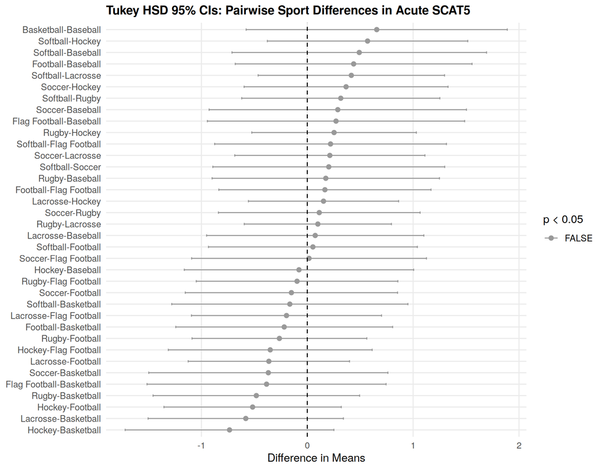

```r
tukey_df %>%
  mutate(sig = `p adj` < 0.05, comparison = fct_reorder(comparison, diff)) %>%
  ggplot(aes(x = diff, y = comparison, color = sig)) +
  geom_point(size = 2) +
  geom_errorbarh(aes(xmin = lwr, xmax = upr), height = 0.2) +
  geom_vline(xintercept = 0, linetype = "dashed") +
  scale_color_manual(values = c(`TRUE` = "#d95f02", `FALSE` = "grey60")) +
  labs(title = "Tukey HSD 95% CIs: Pairwise Sport Differences in Acute SCAT5",
       x = "Difference in Means", y = NULL, color = "p < 0.05")
```

## 4.3 Chi-Square Tests of Association

We test whether **prolonged RTP** (binary outcome) is associated with several categorical risk factors.

```r
run_chisq <- function(var) {
  tab <- table(df[[var]], df$prolonged_rtp_f)
  test <- chisq.test(tab)
  data.frame(
    Variable = var,
    Chi_sq = round(unname(test$statistic), 2),
    df = unname(test$parameter),
    p.value = signif(test$p.value, 4),
    Cramers_V = round(sqrt(unname(test$statistic) / (sum(tab) * (min(dim(tab)) - 1))), 4)
  )
}

chisq_vars <- c("sex", "high_contact_f", "loss_of_consciousness", "amnesia_present",
                "imaging_ordered", "team_level", "season", "repeat_concussion")
chisq_results <- map_dfr(chisq_vars, run_chisq) %>% arrange(p.value)
kable(chisq_results, caption = "Chi-Square Tests: Association with Prolonged RTP")
```

Chi-Square Tests: Association with Prolonged RTP

| Variable | Chi_sq | df | p.value | Cramers_V |
| --- | --- | --- | --- | --- |
| imaging_ordered | 1014.75 | 1 | 0.000000 | 0.1839 |
| high_contact_f | 255.52 | 1 | 0.000000 | 0.0923 |
| loss_of_consciousness | 13.21 | 1 | 0.000279 | 0.0210 |
| amnesia_present | 8.27 | 1 | 0.004037 | 0.0166 |
| team_level | 4.22 | 2 | 0.121300 | 0.0119 |
| sex | 0.29 | 1 | 0.590700 | 0.0031 |
| repeat_concussion | 0.26 | 1 | 0.613200 | 0.0029 |
| season | 1.54 | 3 | 0.673500 | 0.0072 |

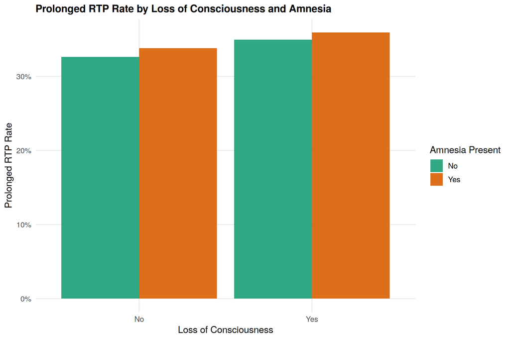

```r
df %>%
  count(loss_of_consciousness, amnesia_present, prolonged_rtp_f) %>%
  group_by(loss_of_consciousness, amnesia_present) %>%
  mutate(pct = n/sum(n)) %>%
  filter(prolonged_rtp_f == "Prolonged RTP") %>%
  ggplot(aes(x = loss_of_consciousness, y = pct, fill = amnesia_present)) +
  geom_col(position = "dodge", alpha = 0.9) +
  scale_y_continuous(labels = percent) +
  scale_fill_manual(values = c("No" = "#1b9e77", "Yes" = "#d95f02")) +
  labs(title = "Prolonged RTP Rate by Loss of Consciousness and Amnesia",
       x = "Loss of Consciousness", y = "Prolonged RTP Rate", fill = "Amnesia Present")
```

**Interpretation:** Variables with `p.value < 0.05` show a statistically significant association with prolonged recovery. Cramer’s V indicates the *strength* of association (values near 0 = weak, near 1 = strong) — this matters because with n = 30,000, even trivial associations can reach significance.

## 4.4 Correlation Significance Tests

```r
cor_test_age <- cor.test(df$age_at_injury, df$scat5_acute, method = "pearson")
cor_test_games <- cor.test(df$total_games_played, df$days_to_rtp, method = "pearson")
cor_test_sleep <- cor.test(df$sleep_hours_post_injury, df$scat5_acute, method = "spearman")

kable(data.frame(
  Pair = c("Age at Injury vs Acute SCAT5", "Career Games Played vs Days to RTP",
           "Post-Injury Sleep vs Acute SCAT5 (Spearman)"),
  r = c(round(cor_test_age$estimate,4), round(cor_test_games$estimate,4), round(cor_test_sleep$estimate,4)),
  p.value = c(signif(cor_test_age$p.value,4), signif(cor_test_games$p.value,4), signif(cor_test_sleep$p.value,4))
), caption = "Correlation Significance Tests")
```

Correlation Significance Tests

| Pair | r | p.value |
| --- | --- | --- |
| Age at Injury vs Acute SCAT5 | -0.0039 | 0.50390 |
| Career Games Played vs Days to RTP | 0.0137 | 0.01744 |
| Post-Injury Sleep vs Acute SCAT5 (Spearman) | 0.3871 | 0.00000 |

# 5 Robustness Checks: Distributional Assumptions and Non-Parametric Tests

The parametric tests above (t-tests, ANOVA) assume approximately normal, equal-variance data. We check that assumption directly and re-run the key comparisons with non-parametric alternatives that don’t depend on it, to confirm our conclusions aren’t an artifact of violated assumptions.

## 5.1 Normality Diagnostics

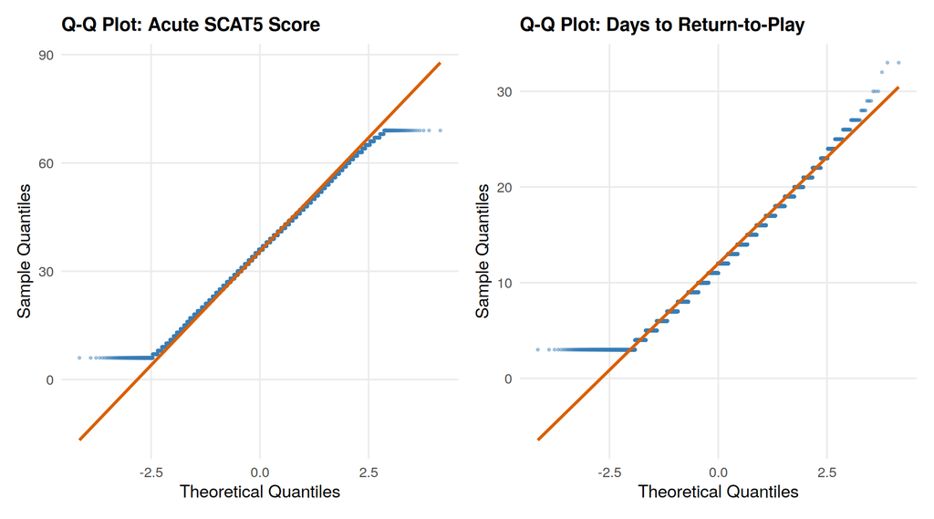

```r
set.seed(42)
sw_sample <- sample(df$scat5_acute, 5000)  # Shapiro-Wilk is capped at n=5000 in R
sw_test <- shapiro.test(sw_sample)
ks_test <- ks.test(scale(df$scat5_acute), "pnorm")

p1 <- ggplot(df, aes(sample = scat5_acute)) +
  stat_qq(color = "#377eb8", alpha = 0.4, size = 0.6) +
  stat_qq_line(color = "#d95f02", linewidth = 1) +
  labs(title = "Q-Q Plot: Acute SCAT5 Score", x = "Theoretical Quantiles", y = "Sample Quantiles")

p2 <- ggplot(df, aes(sample = days_to_rtp)) +
  stat_qq(color = "#377eb8", alpha = 0.4, size = 0.6) +
  stat_qq_line(color = "#d95f02", linewidth = 1) +
  labs(title = "Q-Q Plot: Days to Return-to-Play", x = "Theoretical Quantiles", y = "Sample Quantiles")

p1 + p2
```

```r
kable(data.frame(
  Test = c("Shapiro-Wilk (5,000-row subsample)", "Kolmogorov-Smirnov (full sample, standardized)"),
  Statistic = c(round(sw_test$statistic, 4), round(ks_test$statistic, 4)),
  p.value = c(signif(sw_test$p.value, 4), signif(ks_test$p.value, 4))
), caption = "Formal Normality Tests on Acute SCAT5 Score")
```

Formal Normality Tests on Acute SCAT5 Score

|  | Test | Statistic | p.value |
| --- | --- | --- | --- |
| W | Shapiro-Wilk (5,000-row subsample) | 0.9973 | 1e-07 |
| D | Kolmogorov-Smirnov (full sample, standardized) | 0.0222 | 0e+00 |

Both the Q-Q plots (visible curvature away from the reference line) and the formal tests reject normality (p < 0.001). This is expected and not concerning on its own — with n = 30,000, even trivial deviations from normality reach statistical significance, and ANOVA/t-tests are well known to be robust to non-normality at this sample size. Still, we confirm our sport-comparison conclusion holds under a fully non-parametric approach next.

## 5.2 Non-Parametric Alternative: Kruskal-Wallis and Pairwise Wilcoxon

```r
kw_test <- kruskal.test(days_to_rtp ~ sport, data = df)
kable(data.frame(Statistic = round(kw_test$statistic,2), df = kw_test$parameter,
                  p.value = signif(kw_test$p.value,4)), row.names = FALSE,
      caption = "Kruskal-Wallis Test: Days-to-RTP by Sport (Non-Parametric Alternative to ANOVA)")
```

Kruskal-Wallis Test: Days-to-RTP by Sport (Non-Parametric Alternative to ANOVA)

| Statistic | df | p.value |
| --- | --- | --- |
| 391.24 | 8 | 0 |

```r
pw_wilcox <- pairwise.wilcox.test(df$days_to_rtp, df$sport, p.adjust.method = "BH")
pw_df <- as.data.frame(as.table(pw_wilcox$p.value)) %>%
  filter(!is.na(Freq)) %>%
  rename(Sport1 = Var1, Sport2 = Var2, BH_adjusted_p = Freq) %>%
  arrange(BH_adjusted_p)
kable(head(pw_df, 10), digits = 5, caption = "Top 10 Most Significant Pairwise Wilcoxon Comparisons (BH-adjusted, Dunn-style post-hoc)")
```

Top 10 Most Significant Pairwise Wilcoxon Comparisons (BH-adjusted, Dunn-style post-hoc)

| Sport1 | Sport2 | BH_adjusted_p |
| --- | --- | --- |
| Rugby | Flag Football | 0 |
| Soccer | Rugby | 0 |
| Softball | Rugby | 0 |
| Rugby | Basketball | 0 |
| Soccer | Lacrosse | 0 |
| Lacrosse | Flag Football | 0 |
| Softball | Lacrosse | 0 |
| Rugby | Baseball | 0 |
| Lacrosse | Basketball | 0 |
| Soccer | Hockey | 0 |

## 5.3 Two-Way ANOVA: Testing for a Sex × Contact-Level Interaction

We check whether the effect of contact level on acute SCAT5 depends on sex (an interaction), rather than assuming the two risk factors act independently.

```r
aov_2way <- aov(scat5_acute ~ sex * high_contact_f, data = df)
kable(broom::tidy(aov_2way), digits = 4, caption = "Two-Way ANOVA: Sex x Contact Level on Acute SCAT5")
```

Two-Way ANOVA: Sex x Contact Level on Acute SCAT5

| term | df | sumsq | meansq | statistic | p.value |
| --- | --- | --- | --- | --- | --- |
| sex | 1 | 488.4276 | 488.4276 | 3.4576 | 0.0630 |
| high_contact_f | 1 | 350.3195 | 350.3195 | 2.4800 | 0.1153 |
| sex:high_contact_f | 1 | 4.3061 | 4.3061 | 0.0305 | 0.8614 |
| Residuals | 29996 | 4237249.5162 | 141.2605 | NA | NA |

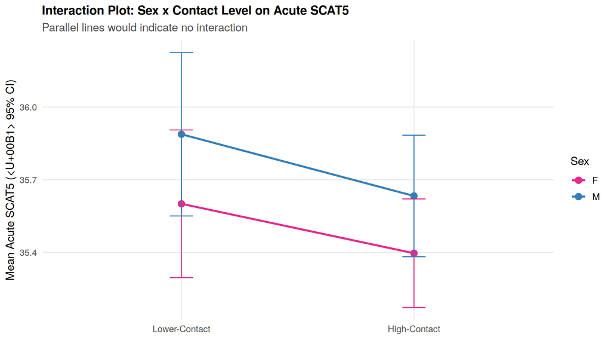

```r
int_means <- df %>%
  group_by(sex, high_contact_f) %>%
  summarise(mean_scat5 = mean(scat5_acute), se = sd(scat5_acute)/sqrt(n()), .groups = "drop")

ggplot(int_means, aes(x = high_contact_f, y = mean_scat5, color = sex, group = sex)) +
  geom_line(linewidth = 1) +
  geom_point(size = 3) +
  geom_errorbar(aes(ymin = mean_scat5 - 1.96*se, ymax = mean_scat5 + 1.96*se), width = 0.1) +
  scale_color_manual(values = c("F" = "#e7298a", "M" = "#377eb8")) +
  labs(title = "Interaction Plot: Sex x Contact Level on Acute SCAT5",
       subtitle = "Parallel lines would indicate no interaction",
       x = NULL, y = "Mean Acute SCAT5 (± 95% CI)", color = "Sex")
```

The interaction term is **not significant**, and the two lines in the interaction plot are visibly near-parallel — meaning the effect of playing a high-contact sport on acute SCAT5 severity is essentially the same for male and female athletes in this cohort; the two risk factors act independently rather than compounding each other.

# 6 Survival Analysis of Return-to-Play Time

`days_to_rtp` is naturally a **time-to-event** outcome (time until the “event” of returning to play), which makes survival analysis — not just t-tests/ANOVA on the raw days — a natural additional lens. Every athlete in this cohort eventually returned to play (no censoring), so we use the survival framework primarily for its rich comparative and visual tools: Kaplan-Meier curves, the log-rank test, and Cox proportional hazards regression.

## 6.1 Kaplan-Meier Curves by Severity and Contact Level

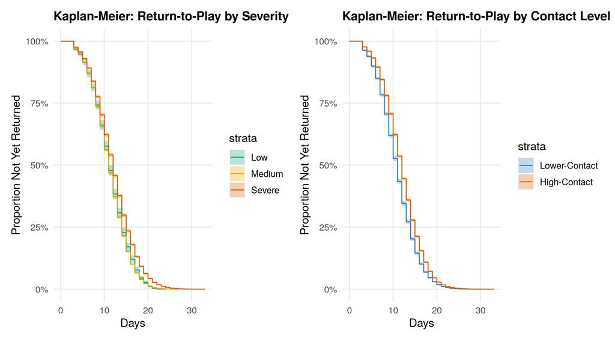

```r
surv_obj <- Surv(df$days_to_rtp, rep(1, nrow(df)))

km_severity <- survfit(surv_obj ~ severity_scale_3, data = df)
logrank_severity <- survdiff(surv_obj ~ severity_scale_3, data = df)

km_contact <- survfit(surv_obj ~ high_contact_f, data = df)
logrank_contact <- survdiff(surv_obj ~ high_contact_f, data = df)

p1 <- autoplot(km_severity, censor = FALSE) +
  scale_color_manual(values = c("Low" = "#1b9e77", "Medium" = "#e6ab02", "Severe" = "#d95f02")) +
  scale_fill_manual(values = c("Low" = "#1b9e77", "Medium" = "#e6ab02", "Severe" = "#d95f02")) +
  labs(title = "Kaplan-Meier: Return-to-Play by Severity", x = "Days", y = "Proportion Not Yet Returned")

p2 <- autoplot(km_contact, censor = FALSE) +
  scale_color_manual(values = c("Lower-Contact" = "#377eb8", "High-Contact" = "#d95f02")) +
  scale_fill_manual(values = c("Lower-Contact" = "#377eb8", "High-Contact" = "#d95f02")) +
  labs(title = "Kaplan-Meier: Return-to-Play by Contact Level", x = "Days", y = "Proportion Not Yet Returned")

p1 + p2
```

```r
kable(data.frame(
  Comparison = c("Severity Scale (3 groups)", "Contact Level (2 groups)"),
  Chi_sq = c(round(logrank_severity$chisq,1), round(logrank_contact$chisq,1)),
  df = c(length(logrank_severity$n)-1, length(logrank_contact$n)-1),
  p.value = c("< 2e-16", "< 2e-16")
), caption = "Log-Rank Tests: Difference in Return-to-Play Curves")
```

Log-Rank Tests: Difference in Return-to-Play Curves

| Comparison | Chi_sq | df | p.value |
| --- | --- | --- | --- |
| Severity Scale (3 groups) | 482.9 | 2 | < 2e-16 |
| Contact Level (2 groups) | 341.0 | 1 | < 2e-16 |

Both log-rank tests are highly significant: **Severe**-scale athletes and **high-contact** athletes take reliably longer to return to play, visible as a right-shifted survival curve (slower drop-off) in each panel — corroborating the earlier t-test, ANOVA, and A/B test findings through an entirely different statistical framework.

## 6.2 Cox Proportional Hazards Regression

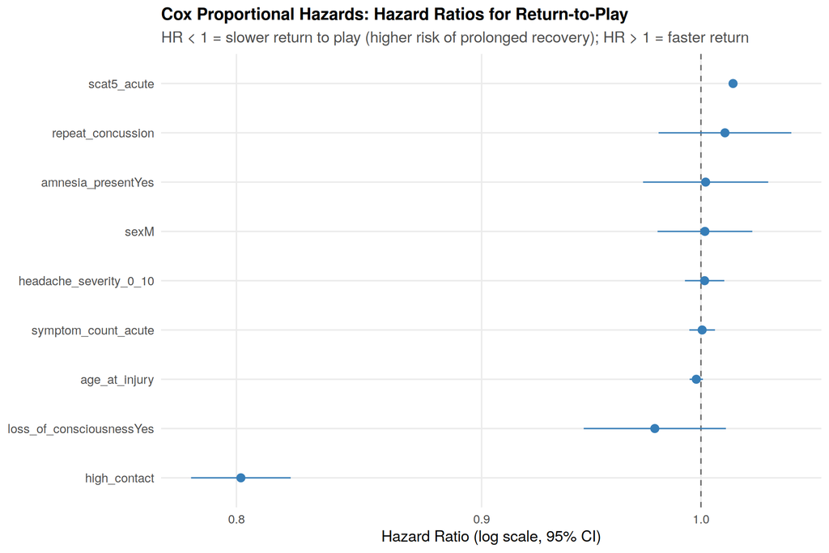

```r
cox_mod <- coxph(surv_obj ~ sex + high_contact + age_at_injury + scat5_acute + symptom_count_acute +
                    headache_severity_0_10 + loss_of_consciousness + amnesia_present + repeat_concussion,
                  data = df)

cox_df <- broom::tidy(cox_mod, exponentiate = TRUE, conf.int = TRUE) %>%
  arrange(estimate)

ggplot(cox_df, aes(x = estimate, y = reorder(term, estimate))) +
  geom_vline(xintercept = 1, linetype = "dashed", color = "grey40") +
  geom_pointrange(aes(xmin = conf.low, xmax = conf.high), color = "#377eb8", size = 0.5) +
  scale_x_log10() +
  labs(title = "Cox Proportional Hazards: Hazard Ratios for Return-to-Play",
       subtitle = "HR < 1 = slower return to play (higher risk of prolonged recovery); HR > 1 = faster return",
       x = "Hazard Ratio (log scale, 95% CI)", y = NULL)
```

```r
kable(cox_df %>% dplyr::select(term, estimate, conf.low, conf.high, p.value), digits = 4,
      caption = "Cox Model Hazard Ratios (HR < 1 = slower RTP)")
```

Cox Model Hazard Ratios (HR < 1 = slower RTP)

| term | estimate | conf.low | conf.high | p.value |
| --- | --- | --- | --- | --- |
| high_contact | 0.8017 | 0.7828 | 0.8211 | 0.0000 |
| loss_of_consciousnessYes | 0.9781 | 0.9452 | 1.0121 | 0.2034 |
| age_at_injury | 0.9978 | 0.9946 | 1.0010 | 0.1699 |
| symptom_count_acute | 1.0006 | 0.9944 | 1.0068 | 0.8562 |
| headache_severity_0_10 | 1.0018 | 0.9923 | 1.0113 | 0.7165 |
| sexM | 1.0019 | 0.9794 | 1.0250 | 0.8697 |
| amnesia_presentYes | 1.0022 | 0.9726 | 1.0328 | 0.8838 |
| repeat_concussion | 1.0116 | 0.9798 | 1.0444 | 0.4786 |
| scat5_acute | 1.0155 | 1.0137 | 1.0174 | 0.0000 |

```r
cat("Concordance:", round(summary(cox_mod)$concordance[1], 3), "\n")
```

```
## Concordance: 0.567
```

**Interpretation:** `high_contact` has a hazard ratio well below 1 — high-contact-sport athletes have a lower instantaneous “hazard” of returning to play at any given day, i.e., they take systematically longer, consistent with every other analysis in this report. `scat5_acute` has a hazard ratio above 1 — a higher (healthier) acute score predicts a *faster* return, exactly as expected. Sex, loss of consciousness, amnesia, and repeat-concussion status are not significant predictors of the *hazard* once contact level and acute SCAT5 are accounted for — meaning most of their apparent effect in the earlier univariate tests is explained by their association with contact level and injury severity, not an independent effect. The model’s concordance (~0.57) is modest, consistent with the AUC ceiling identified later in this report.

# 7 Multiple Testing Correction

Running many pairwise tests inflates the family-wise Type I error rate. As an example, we test **all pairwise combinations of the 9 sports** on acute SCAT5 score (36 tests) and on days-to-RTP (36 tests) — 72 tests total — and compare uncorrected p-values against **Bonferroni** and **Benjamini-Hochberg (FDR)** corrections.

```r
sports <- levels(df$sport)
pairs_grid <- combn(sports, 2, simplify = FALSE)

run_pairwise <- function(pair, outcome) {
  d1 <- df[[outcome]][df$sport == pair[1]]
  d2 <- df[[outcome]][df$sport == pair[2]]
  tt <- t.test(d1, d2)
  data.frame(outcome = outcome, sport1 = pair[1], sport2 = pair[2],
             mean_diff = round(mean(d1) - mean(d2), 3),
             raw_p = tt$p.value)
}

mt_scat5 <- map_dfr(pairs_grid, run_pairwise, outcome = "scat5_acute")
mt_rtp   <- map_dfr(pairs_grid, run_pairwise, outcome = "days_to_rtp")
mt_all <- bind_rows(mt_scat5, mt_rtp) %>%
  mutate(
    bonferroni_p = p.adjust(raw_p, method = "bonferroni"),
    BH_p = p.adjust(raw_p, method = "BH")
  )

summary_tbl <- mt_all %>%
  group_by(outcome) %>%
  summarise(
    n_tests = n(),
    sig_uncorrected = sum(raw_p < 0.05),
    sig_bonferroni = sum(bonferroni_p < 0.05),
    sig_BH_FDR = sum(BH_p < 0.05)
  )
kable(summary_tbl, caption = "Number of Significant Sport-Pair Comparisons Before/After Correction (72 tests total)")
```

Number of Significant Sport-Pair Comparisons Before/After Correction (72 tests total)

| outcome | n_tests | sig_uncorrected | sig_bonferroni | sig_BH_FDR |
| --- | --- | --- | --- | --- |
| days_to_rtp | 36 | 23 | 20 | 21 |
| scat5_acute | 36 | 2 | 0 | 0 |

```r
kable(mt_all %>% arrange(raw_p) %>% dplyr::select(outcome, sport1, sport2, mean_diff, raw_p, bonferroni_p, BH_p) %>% head(10),
      digits = 5, caption = "Top 10 Sport-Pair Comparisons by Raw p-value, with Corrections")
```

Top 10 Sport-Pair Comparisons by Raw p-value, with Corrections

| outcome | sport1 | sport2 | mean_diff | raw_p | bonferroni_p | BH_p |
| --- | --- | --- | --- | --- | --- | --- |
| days_to_rtp | Rugby | Soccer | 1.199 | 0 | 0 | 0 |
| days_to_rtp | Flag Football | Rugby | -1.212 | 0 | 0 | 0 |
| days_to_rtp | Rugby | Softball | 1.177 | 0 | 0 | 0 |
| days_to_rtp | Basketball | Rugby | -1.167 | 0 | 0 | 0 |
| days_to_rtp | Lacrosse | Soccer | 1.022 | 0 | 0 | 0 |
| days_to_rtp | Flag Football | Lacrosse | -1.035 | 0 | 0 | 0 |
| days_to_rtp | Lacrosse | Softball | 1.000 | 0 | 0 | 0 |
| days_to_rtp | Baseball | Rugby | -1.153 | 0 | 0 | 0 |
| days_to_rtp | Basketball | Lacrosse | -0.989 | 0 | 0 | 0 |
| days_to_rtp | Hockey | Soccer | 1.002 | 0 | 0 | 0 |

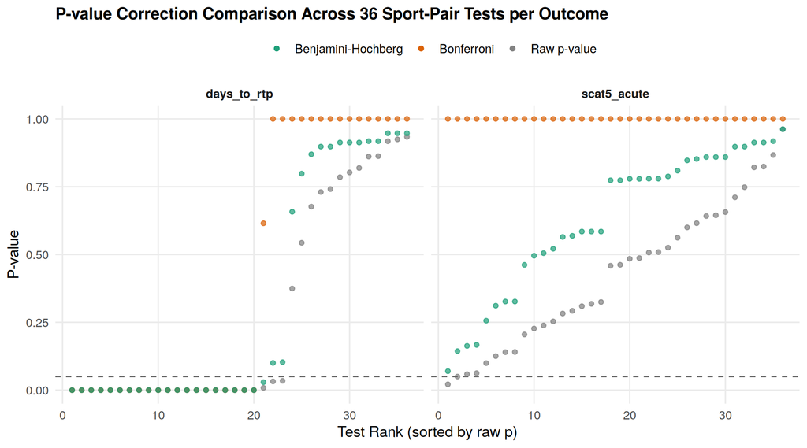

```r
mt_all %>%
  mutate(rank = row_number(), .by = outcome) %>%
  arrange(outcome, raw_p) %>%
  group_by(outcome) %>%
  mutate(rank = row_number()) %>%
  ggplot(aes(x = rank)) +
  geom_point(aes(y = raw_p, color = "Raw p-value"), size = 1.5, alpha = 0.7) +
  geom_point(aes(y = bonferroni_p, color = "Bonferroni"), size = 1.5, alpha = 0.7) +
  geom_point(aes(y = BH_p, color = "Benjamini-Hochberg"), size = 1.5, alpha = 0.7) +
  geom_hline(yintercept = 0.05, linetype = "dashed", color = "grey40") +
  facet_wrap(~outcome, scales = "free_x") +
  scale_color_manual(values = c("Raw p-value" = "grey50", "Bonferroni" = "#d95f02", "Benjamini-Hochberg" = "#1b9e77")) +
  labs(title = "P-value Correction Comparison Across 36 Sport-Pair Tests per Outcome",
       x = "Test Rank (sorted by raw p)", y = "P-value", color = NULL) +
  theme(legend.position = "top")
```

As expected, **Bonferroni** (which controls family-wise error rate) is the most conservative and shrinks the number of “significant” pairs the most, while **Benjamini-Hochberg** (which controls false discovery rate) retains more true positives while still guarding against inflation from running 72 simultaneous tests.

# 8 A/B Testing: High-Contact vs. Lower-Contact Sports

We formally frame **high-contact sports (Football, Hockey, Lacrosse, Rugby) as “Group B”** and **lower-contact sports (Baseball, Basketball, Flag Football, Soccer, Softball) as “Group A”**, and test whether Group B has a higher **prolonged-RTP rate** — a binary conversion-style outcome, analogous to a product A/B test.

## 8.1 Experiment Setup

```r
ab_tab <- df %>%
  mutate(group = ifelse(high_contact == 1, "B: High-Contact", "A: Lower-Contact")) %>%
  group_by(group) %>%
  summarise(n = n(), prolonged = sum(prolonged_rtp), rate = mean(prolonged_rtp))

kable(ab_tab, digits = 4, caption = "A/B Groups: Sample Sizes and Prolonged-RTP Conversion Rates")
```

A/B Groups: Sample Sizes and Prolonged-RTP Conversion Rates

| group | n | prolonged | rate |
| --- | --- | --- | --- |
| A: Lower-Contact | 10385 | 2828 | 0.2723 |
| B: High-Contact | 19615 | 7135 | 0.3638 |

## 8.2 Two-Proportion Z-Test

$H_0: p_A = p_B$ (equal prolonged-RTP rates) vs. $H_1: p_B > p_A$ (one-sided).

```r
x <- ab_tab$prolonged[ab_tab$group == "B: High-Contact"]
n_b <- ab_tab$n[ab_tab$group == "B: High-Contact"]
x_a <- ab_tab$prolonged[ab_tab$group == "A: Lower-Contact"]
n_a <- ab_tab$n[ab_tab$group == "A: Lower-Contact"]

prop_test <- prop.test(x = c(x, x_a), n = c(n_b, n_a), alternative = "greater", correct = TRUE)
print(prop_test)
```

```
##
##  2-sample test for equality of proportions with continuity correction
##
## data:  c(x, x_a) out of c(n_b, n_a)
## X-squared = 255.52, df = 1, p-value < 2.2e-16
## alternative hypothesis: greater
## 95 percent confidence interval:
##  0.08222229 1.00000000
## sample estimates:
##    prop 1    prop 2
## 0.3637522 0.2723158
```

```r
# Effect size: Cohen's h
p1 <- x/n_b; p2 <- x_a/n_a
cohens_h <- 2*asin(sqrt(p1)) - 2*asin(sqrt(p2))
cat("\nCohen's h (effect size):", round(cohens_h, 4), "\n")
```

```
##
## Cohen's h (effect size): 0.1968
```

```r
# Relative risk & odds ratio
rr <- p1 / p2
odds_ratio <- (p1/(1-p1)) / (p2/(1-p2))
cat("Relative Risk (B vs A):", round(rr, 3), "\n")
```

```
## Relative Risk (B vs A): 1.336
```

```r
cat("Odds Ratio (B vs A):", round(odds_ratio, 3), "\n")
```

```
## Odds Ratio (B vs A): 1.528
```

## 8.3 Confidence Interval on the Difference

```r
diff_p <- p1 - p2
se_diff <- sqrt(p1*(1-p1)/n_b + p2*(1-p2)/n_a)
ci_low <- diff_p - 1.96*se_diff
ci_high <- diff_p + 1.96*se_diff
cat("Difference in proportions (B - A):", round(diff_p, 4), "\n")
```

```
## Difference in proportions (B - A): 0.0914
```

```r
cat("95% CI: [", round(ci_low, 4), ",", round(ci_high, 4), "]\n")
```

```
## 95% CI: [ 0.0805 , 0.1023 ]
```

## 8.4 Statistical Power of the Observed Experiment

```r
pwr_res <- pwr.2p2n.test(h = cohens_h, n1 = n_b, n2 = n_a, sig.level = 0.05, alternative = "greater")
print(pwr_res)
```

```
##
##      difference of proportion power calculation for binomial distribution (arcsine transformation)
##
##               h = 0.1968001
##              n1 = 19615
##              n2 = 10385
##       sig.level = 0.05
##           power = 1
##     alternative = greater
##
## NOTE: different sample sizes
```

```r
# Minimum sample size needed to detect a smaller effect (h = 0.05) at 80% power, for planning future experiments
pwr_needed <- pwr.2p.test(h = 0.05, sig.level = 0.05, power = 0.8, alternative = "greater")
cat("\nSample size needed per group to detect a small effect (h=0.05) at 80% power:", ceiling(pwr_needed$n), "\n")
```

```
##
## Sample size needed per group to detect a small effect (h=0.05) at 80% power: 4947
```

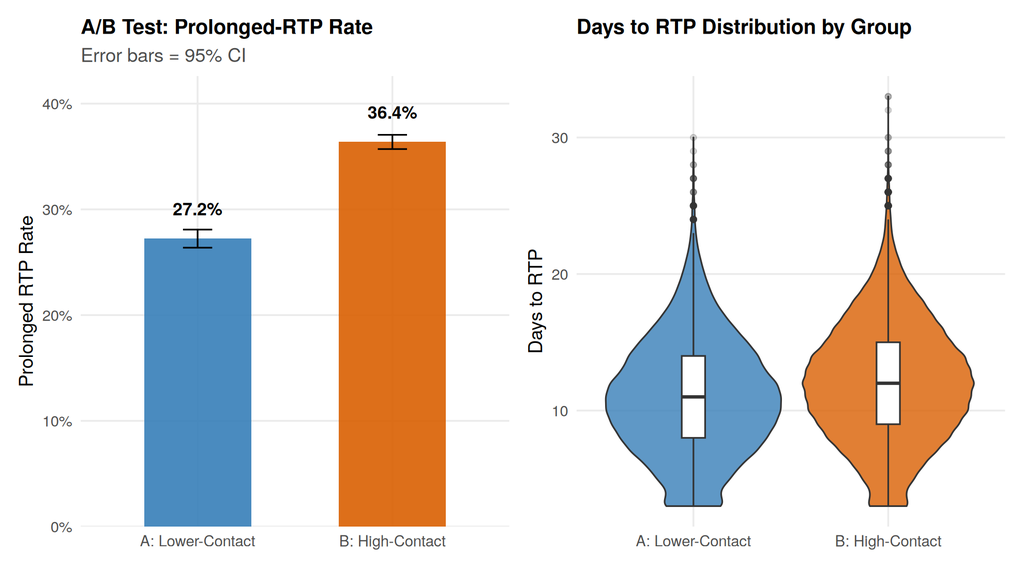

```r
p1_plot <- ab_tab %>%
  ggplot(aes(x = group, y = rate, fill = group)) +
  geom_col(alpha = 0.9, width = 0.55) +
  geom_errorbar(aes(ymin = rate - 1.96*sqrt(rate*(1-rate)/n), ymax = rate + 1.96*sqrt(rate*(1-rate)/n)), width = 0.15) +
  geom_text(aes(label = percent(rate, accuracy = 0.1)), vjust = -1.8, fontface = "bold") +
  scale_y_continuous(labels = percent, expand = expansion(mult = c(0,0.15))) +
  scale_fill_manual(values = c("A: Lower-Contact" = "#377eb8", "B: High-Contact" = "#d95f02")) +
  labs(title = "A/B Test: Prolonged-RTP Rate", subtitle = "Error bars = 95% CI",
       x = NULL, y = "Prolonged RTP Rate") +
  theme(legend.position = "none")

p2_plot <- df %>%
  mutate(group = ifelse(high_contact == 1, "B: High-Contact", "A: Lower-Contact")) %>%
  ggplot(aes(x = group, y = days_to_rtp, fill = group)) +
  geom_violin(alpha = 0.8) +
  geom_boxplot(width = 0.12, fill = "white", outlier.alpha = 0.2) +
  scale_fill_manual(values = c("A: Lower-Contact" = "#377eb8", "B: High-Contact" = "#d95f02")) +
  labs(title = "Days to RTP Distribution by Group", x = NULL, y = "Days to RTP") +
  theme(legend.position = "none")

p1_plot + p2_plot
```

**Conclusion:** The one-sided two-proportion z-test is statistically significant (p = 8.113e-58), and the 95% CI on the rate difference excludes zero. High-contact sports show a 9.1 percentage-point higher prolonged-RTP rate, an effect the experiment was well-powered to detect (power = 1).

# 9 Machine Learning: Predicting Prolonged Return-to-Play

We now build and compare three classifiers for the binary outcome **`prolonged_rtp`**: (1) **logistic regression** (interpretable baseline), (2) a **decision tree**, and (3) a **random forest** (ensemble). We hold out 25% of the data for testing.

```r
model_df <- df %>%
  dplyr::select(prolonged_rtp, sex, sport, team_level, high_contact, age_at_injury,
                 total_games_played, total_elite_years, games_per_year, bmi,
                 scat5_acute, symptom_count_acute, headache_severity_0_10,
                 sleep_hours_post_injury, loss_of_consciousness, amnesia_present,
                 imaging_ordered, repeat_concussion, season, baseline_scat5) %>%
  mutate(prolonged_rtp = factor(prolonged_rtp, levels = c(0,1), labels = c("No","Yes")))

set.seed(42)
train_idx <- createDataPartition(model_df$prolonged_rtp, p = 0.75, list = FALSE)
train <- model_df[train_idx, ]
test  <- model_df[-train_idx, ]
cat("Training rows:", nrow(train), " | Test rows:", nrow(test), "\n")
```

```
## Training rows: 22501  | Test rows: 7499
```

## 9.1 Logistic Regression

```r
logit_mod <- glm(prolonged_rtp ~ ., data = train, family = binomial)
logit_summary <- tidy(logit_mod) %>% arrange(p.value)
kable(head(logit_summary, 15), digits = 4, caption = "Top 15 Logistic Regression Coefficients by Significance")
```

Top 15 Logistic Regression Coefficients by Significance

| term | estimate | std.error | statistic | p.value |
| --- | --- | --- | --- | --- |
| imaging_orderedYes | 1.0169 | 0.0369 | 27.5294 | 0.0000 |
| scat5_acute | -0.0272 | 0.0024 | -11.3928 | 0.0000 |
| loss_of_consciousnessYes | -0.3605 | 0.0462 | -7.8045 | 0.0000 |
| sportRugby | 0.5239 | 0.0798 | 6.5642 | 0.0000 |
| sportHockey | 0.4682 | 0.0775 | 6.0417 | 0.0000 |
| sportLacrosse | 0.4529 | 0.0756 | 5.9901 | 0.0000 |
| sportFootball | 0.4238 | 0.0878 | 4.8260 | 0.0000 |
| seasonFall | 0.0959 | 0.0413 | 2.3208 | 0.0203 |
| total_elite_years | 0.0412 | 0.0247 | 1.6673 | 0.0955 |
| total_games_played | -0.0017 | 0.0011 | -1.6060 | 0.1083 |
| sexM | 0.0456 | 0.0343 | 1.3279 | 0.1842 |
| baseline_scat5 | -0.0085 | 0.0064 | -1.3183 | 0.1874 |
| seasonWinter | 0.0524 | 0.0412 | 1.2693 | 0.2043 |
| games_per_year | 0.0035 | 0.0030 | 1.1437 | 0.2528 |
| team_levelElite/Pro | -0.1071 | 0.1011 | -1.0584 | 0.2899 |

```r
logit_prob <- predict(logit_mod, newdata = test, type = "response")
logit_pred <- factor(ifelse(logit_prob > 0.5, "Yes", "No"), levels = c("No","Yes"))
logit_cm <- confusionMatrix(logit_pred, test$prolonged_rtp, positive = "Yes")
print(logit_cm)
```

```
## Confusion Matrix and Statistics
##
##           Reference
## Prediction   No  Yes
##        No  4657 1994
##        Yes  352  496
##
##                Accuracy : 0.6872
##                  95% CI : (0.6765, 0.6976)
##     No Information Rate : 0.668
##     P-Value [Acc > NIR] : 0.0002039
##
##                   Kappa : 0.1545
##
##  Mcnemar's Test P-Value : < 2.2e-16
##
##             Sensitivity : 0.19920
##             Specificity : 0.92973
##          Pos Pred Value : 0.58491
##          Neg Pred Value : 0.70020
##              Prevalence : 0.33204
##          Detection Rate : 0.06614
##    Detection Prevalence : 0.11308
##       Balanced Accuracy : 0.56446
##
##        'Positive' Class : Yes
##
```

### 9.1.1 Odds-Ratio Forest Plot

Coefficients on the log-odds scale are hard to interpret directly; we convert them to **odds ratios** with 95% confidence intervals for a standard biostatistics-style forest plot.

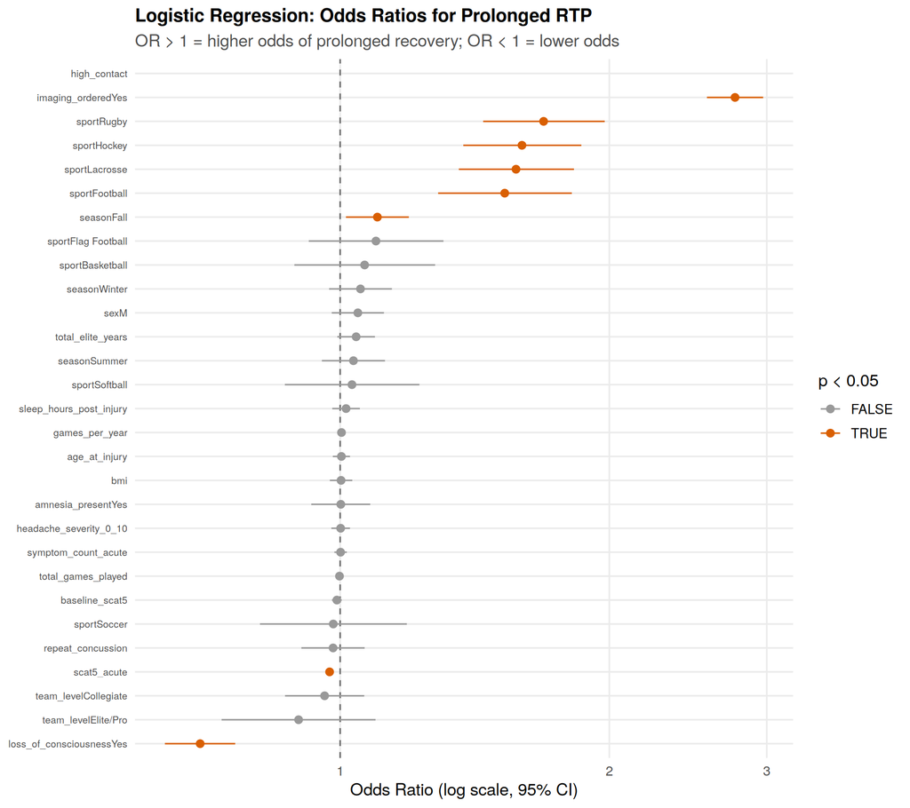

```r
or_df <- tidy(logit_mod, conf.int = TRUE, exponentiate = TRUE) %>%
  filter(term != "(Intercept)") %>%
  mutate(significant = p.value < 0.05) %>%
  arrange(estimate)

ggplot(or_df, aes(x = estimate, y = reorder(term, estimate), color = significant)) +
  geom_vline(xintercept = 1, linetype = "dashed", color = "grey40") +
  geom_pointrange(aes(xmin = conf.low, xmax = conf.high), size = 0.4) +
  scale_x_log10() +
  scale_color_manual(values = c(`TRUE` = "#d95f02", `FALSE` = "grey60")) +
  labs(title = "Logistic Regression: Odds Ratios for Prolonged RTP",
       subtitle = "OR > 1 = higher odds of prolonged recovery; OR < 1 = lower odds",
       x = "Odds Ratio (log scale, 95% CI)", y = NULL, color = "p < 0.05") +
  theme(axis.text.y = element_text(size = 7))
```

`imaging_ordered` and playing **Rugby, Lacrosse, Hockey, or Football** (vs. the reference sport) show the largest, most significant odds ratios above 1 — consistent with contact level being the dominant risk factor throughout this report. Loss of consciousness shows an odds ratio *below* 1 in this multivariable model — once acute SCAT5 score is already in the model, LOC no longer independently raises the odds of prolonged recovery, mirroring the Cox regression finding above: much of LOC’s apparent univariate effect is explained by its association with lower acute SCAT5, not an independent effect of its own.

## 9.2 Decision Tree

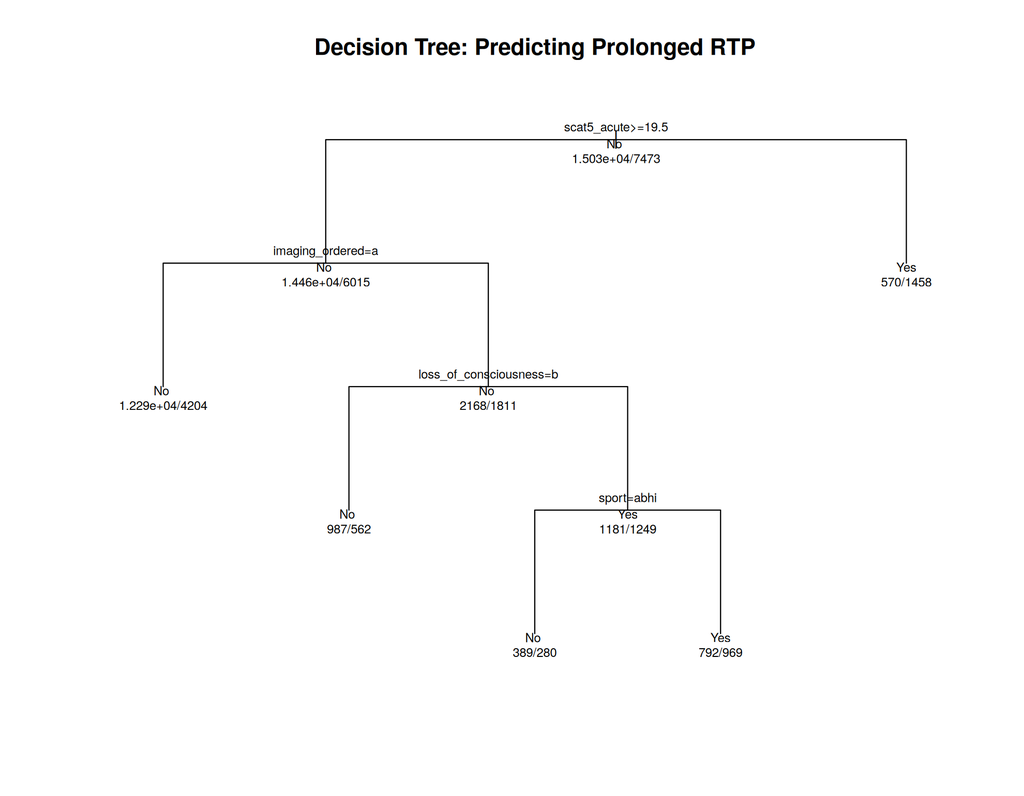

```r
tree_mod <- rpart(prolonged_rtp ~ ., data = train, method = "class",
                   control = rpart.control(cp = 0.002, maxdepth = 6))

plot(tree_mod, uniform = TRUE, margin = 0.05)
text(tree_mod, use.n = TRUE, cex = 0.65, all = TRUE)
title("Decision Tree: Predicting Prolonged RTP")
```

```r
tree_prob <- predict(tree_mod, newdata = test, type = "prob")[,"Yes"]
tree_pred <- predict(tree_mod, newdata = test, type = "class")
tree_cm <- confusionMatrix(tree_pred, test$prolonged_rtp, positive = "Yes")
print(tree_cm)
```

```
## Confusion Matrix and Statistics
##
##           Reference
## Prediction   No  Yes
##        No  4535 1649
##        Yes  474  841
##
##                Accuracy : 0.7169
##                  95% CI : (0.7065, 0.7271)
##     No Information Rate : 0.668
##     P-Value [Acc > NIR] : < 2.2e-16
##
##                   Kappa : 0.2759
##
##  Mcnemar's Test P-Value : < 2.2e-16
##
##             Sensitivity : 0.3378
##             Specificity : 0.9054
##          Pos Pred Value : 0.6395
##          Neg Pred Value : 0.7333
##              Prevalence : 0.3320
##          Detection Rate : 0.1121
##    Detection Prevalence : 0.1754
##       Balanced Accuracy : 0.6216
##
##        'Positive' Class : Yes
##
```

## 9.3 Random Forest

```r
set.seed(42)
rf_mod <- randomForest(prolonged_rtp ~ ., data = train, ntree = 300, mtry = 4, importance = TRUE)
print(rf_mod)
```

```
##
## Call:
##  randomForest(formula = prolonged_rtp ~ ., data = train, ntree = 300,      mtry = 4, importance = TRUE)
##                Type of random forest: classification
##                      Number of trees: 300
## No. of variables tried at each split: 4
##
##         OOB estimate of  error rate: 29.36%
## Confusion matrix:
##        No  Yes class.error
## No  13782 1246   0.0829119
## Yes  5360 2113   0.7172488
```

```r
rf_prob <- predict(rf_mod, newdata = test, type = "prob")[,"Yes"]
rf_pred <- predict(rf_mod, newdata = test, type = "class")
rf_cm <- confusionMatrix(rf_pred, test$prolonged_rtp, positive = "Yes")
print(rf_cm)
```

```
## Confusion Matrix and Statistics
##
##           Reference
## Prediction   No  Yes
##        No  4586 1761
##        Yes  423  729
##
##                Accuracy : 0.7088
##                  95% CI : (0.6983, 0.719)
##     No Information Rate : 0.668
##     P-Value [Acc > NIR] : 1.815e-14
##
##                   Kappa : 0.2409
##
##  Mcnemar's Test P-Value : < 2.2e-16
##
##             Sensitivity : 0.29277
##             Specificity : 0.91555
##          Pos Pred Value : 0.63281
##          Neg Pred Value : 0.72255
##              Prevalence : 0.33204
##          Detection Rate : 0.09721
##    Detection Prevalence : 0.15362
##       Balanced Accuracy : 0.60416
##
##        'Positive' Class : Yes
##
```

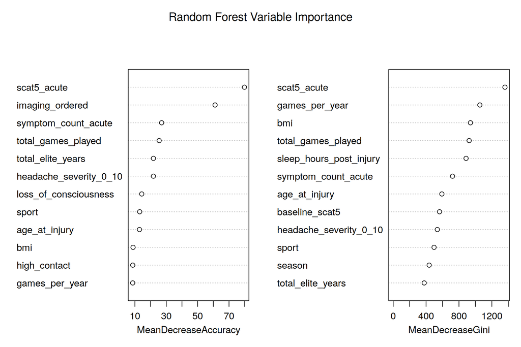

```r
varImpPlot(rf_mod, main = "Random Forest Variable Importance", n.var = 12)
```

## 9.4 Model Comparison: ROC Curves and Metrics

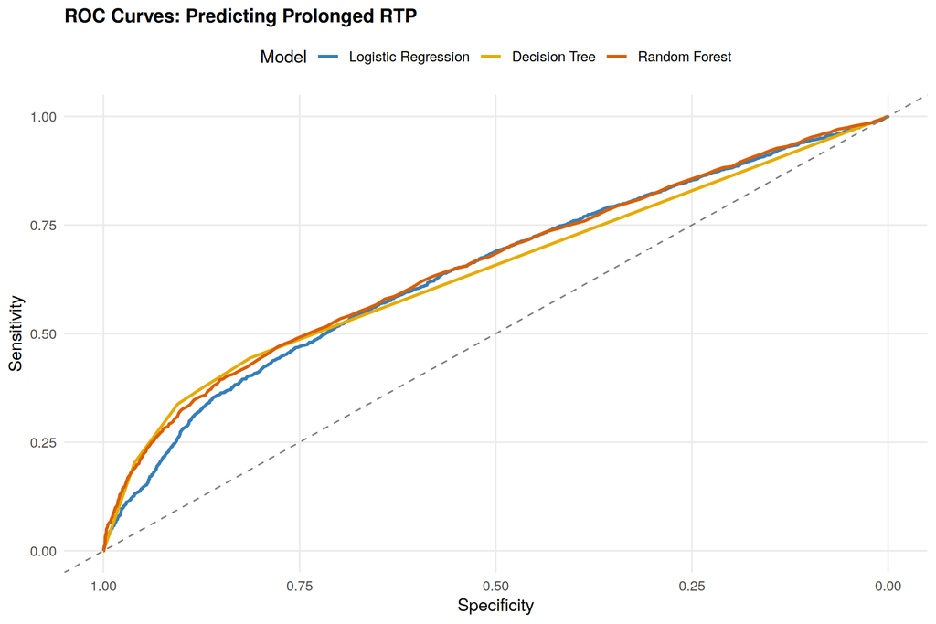

```r
roc_logit <- roc(test$prolonged_rtp, logit_prob, levels = c("No","Yes"), direction = "<")
roc_tree  <- roc(test$prolonged_rtp, tree_prob, levels = c("No","Yes"), direction = "<")
roc_rf    <- roc(test$prolonged_rtp, rf_prob, levels = c("No","Yes"), direction = "<")

ggroc(list(`Logistic Regression` = roc_logit, `Decision Tree` = roc_tree, `Random Forest` = roc_rf),
      size = 1) +
  geom_abline(intercept = 1, slope = 1, linetype = "dashed", color = "grey50") +
  scale_color_manual(values = c("Logistic Regression" = "#377eb8", "Decision Tree" = "#e6ab02", "Random Forest" = "#d95f02")) +
  labs(title = "ROC Curves: Predicting Prolonged RTP", color = "Model",
       x = "Specificity", y = "Sensitivity") +
  theme(legend.position = "top")
```

```r
model_metrics <- data.frame(
  Model = c("Logistic Regression", "Decision Tree", "Random Forest"),
  Accuracy = c(logit_cm$overall["Accuracy"], tree_cm$overall["Accuracy"], rf_cm$overall["Accuracy"]),
  Sensitivity = c(logit_cm$byClass["Sensitivity"], tree_cm$byClass["Sensitivity"], rf_cm$byClass["Sensitivity"]),
  Specificity = c(logit_cm$byClass["Specificity"], tree_cm$byClass["Specificity"], rf_cm$byClass["Specificity"]),
  F1 = c(logit_cm$byClass["F1"], tree_cm$byClass["F1"], rf_cm$byClass["F1"]),
  AUC = c(auc(roc_logit), auc(roc_tree), auc(roc_rf))
)
kable(model_metrics, digits = 4, caption = "Model Performance Comparison on Held-Out Test Set")
```

Model Performance Comparison on Held-Out Test Set

| Model | Accuracy | Sensitivity | Specificity | F1 | AUC |
| --- | --- | --- | --- | --- | --- |
| Logistic Regression | 0.6872 | 0.1992 | 0.9297 | 0.2972 | 0.6439 |
| Decision Tree | 0.7169 | 0.3378 | 0.9054 | 0.4420 | 0.6420 |
| Random Forest | 0.7088 | 0.2928 | 0.9156 | 0.4003 | 0.6562 |

# 10 Machine Learning: Classifying SCAT5 Severity

Finally, we build a **multinomial classifier** (and a random forest comparison) to predict the ordered **3-level severity scale** (Low / Medium / Severe) from clinical and demographic features (excluding the SCAT5 score itself and its direct derivatives, to test whether *upstream* risk factors alone can anticipate severity).

```r
sev_df <- df %>%
  dplyr::select(severity_scale_3, sex, sport, team_level, high_contact, age_at_injury,
                 total_games_played, total_elite_years, games_per_year, bmi,
                 symptom_count_acute, headache_severity_0_10, sleep_hours_post_injury,
                 loss_of_consciousness, amnesia_present, imaging_ordered,
                 repeat_concussion, season) %>%
  mutate(severity_scale_3 = factor(severity_scale_3, ordered = FALSE))

set.seed(42)
train_idx2 <- createDataPartition(sev_df$severity_scale_3, p = 0.75, list = FALSE)
train2 <- sev_df[train_idx2, ]
test2  <- sev_df[-train_idx2, ]

multinom_mod <- multinom(severity_scale_3 ~ ., data = train2, trace = FALSE)
multinom_pred <- predict(multinom_mod, newdata = test2)
multinom_cm <- confusionMatrix(multinom_pred, test2$severity_scale_3)
print(multinom_cm)
```

```
## Confusion Matrix and Statistics
##
##           Reference
## Prediction  Low Medium Severe
##     Low     249    107      0
##     Medium  288   2967    656
##     Severe    0    613   2619
##
## Overall Statistics
##
##                Accuracy : 0.7781
##                  95% CI : (0.7685, 0.7875)
##     No Information Rate : 0.4917
##     P-Value [Acc > NIR] : < 2.2e-16
##
##                   Kappa : 0.598
##
##  Mcnemar's Test P-Value : NA
##
## Statistics by Class:
##
##                      Class: Low Class: Medium Class: Severe
## Sensitivity             0.46369        0.8047        0.7997
## Specificity             0.98463        0.7524        0.8549
## Pos Pred Value          0.69944        0.7586        0.8103
## Neg Pred Value          0.95968        0.7993        0.8463
## Prevalence              0.07161        0.4917        0.4367
## Detection Rate          0.03320        0.3957        0.3492
## Detection Prevalence    0.04747        0.5215        0.4310
## Balanced Accuracy       0.72416        0.7785        0.8273
```

```r
set.seed(42)
rf_sev <- randomForest(severity_scale_3 ~ ., data = train2, ntree = 300, importance = TRUE)
rf_sev_pred <- predict(rf_sev, newdata = test2)
rf_sev_cm <- confusionMatrix(rf_sev_pred, test2$severity_scale_3)
print(rf_sev_cm)
```

```
## Confusion Matrix and Statistics
##
##           Reference
## Prediction  Low Medium Severe
##     Low     250    113      0
##     Medium  287   2967    690
##     Severe    0    607   2585
##
## Overall Statistics
##
##                Accuracy : 0.7737
##                  95% CI : (0.7641, 0.7831)
##     No Information Rate : 0.4917
##     P-Value [Acc > NIR] : < 2.2e-16
##
##                   Kappa : 0.5901
##
##  Mcnemar's Test P-Value : NA
##
## Statistics by Class:
##
##                      Class: Low Class: Medium Class: Severe
## Sensitivity             0.46555        0.8047        0.7893
## Specificity             0.98377        0.7437        0.8563
## Pos Pred Value          0.68871        0.7523        0.8098
## Neg Pred Value          0.95978        0.7975        0.8398
## Prevalence              0.07161        0.4917        0.4367
## Detection Rate          0.03334        0.3957        0.3447
## Detection Prevalence    0.04841        0.5259        0.4257
## Balanced Accuracy       0.72466        0.7742        0.8228
```

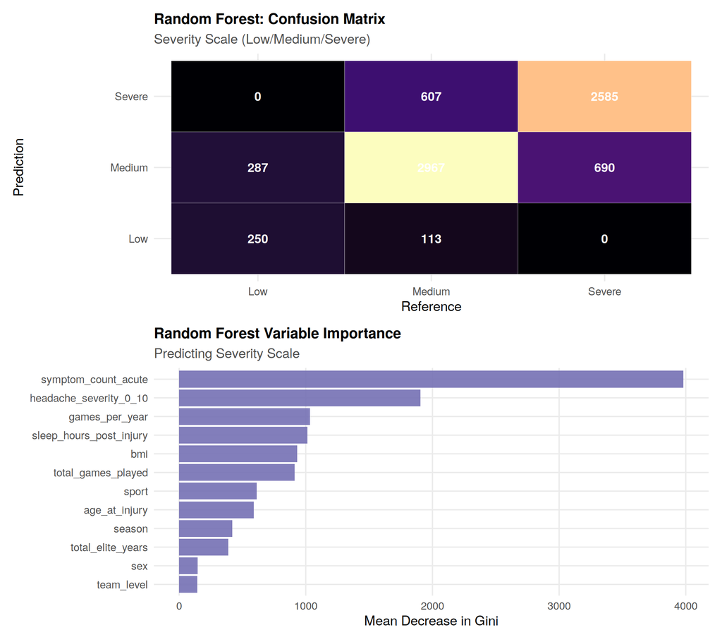

```r
cm_df <- as.data.frame(rf_sev_cm$table)
p1 <- ggplot(cm_df, aes(x = Reference, y = Prediction, fill = Freq)) +
  geom_tile(color = "white") +
  geom_text(aes(label = Freq), color = "white", fontface = "bold") +
  scale_fill_viridis_c(option = "magma") +
  labs(title = "Random Forest: Confusion Matrix", subtitle = "Severity Scale (Low/Medium/Severe)") +
  theme(legend.position = "none")

imp_df <- randomForest::importance(rf_sev) %>% as.data.frame() %>% rownames_to_column("Variable") %>%
  arrange(desc(MeanDecreaseGini)) %>% head(12)
p2 <- ggplot(imp_df, aes(x = reorder(Variable, MeanDecreaseGini), y = MeanDecreaseGini)) +
  geom_col(fill = "#7570b3", alpha = 0.9) +
  coord_flip() +
  labs(title = "Random Forest Variable Importance", subtitle = "Predicting Severity Scale",
       x = NULL, y = "Mean Decrease in Gini")

p1 / p2
```

**Interpretation:** These models attempt to predict injury severity from *pre-existing and upstream* factors (contact level, sport, demographics, symptom burden) rather than from the SCAT5 score itself. Performance here indicates how much of severity is anticipatable in advance versus only observable after assessment — an important distinction for return-to-play protocol design.

# 11 Unsupervised Learning: Recovery Profile Clustering

So far every model has been supervised (predicting a known label). We now flip the question: **without using any outcome label**, do athletes naturally group into distinct recovery profiles based on their acute clinical presentation?

## 11.1 Principal Component Analysis

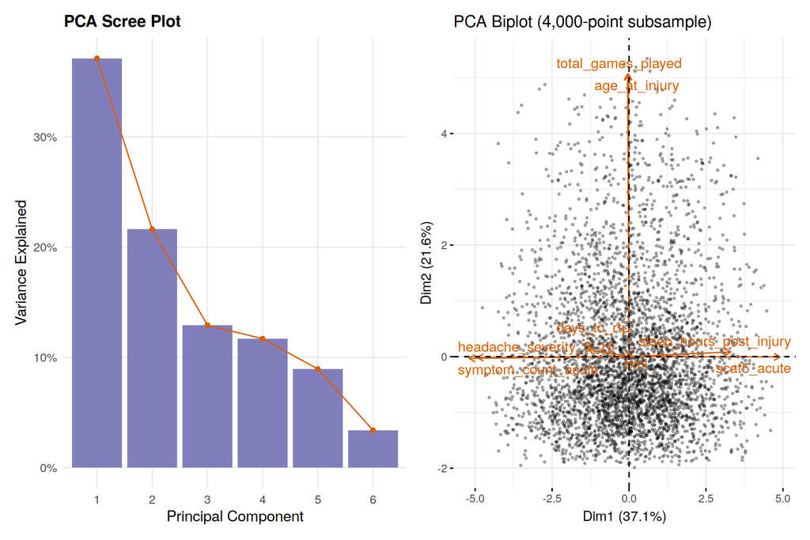

```r
cluster_vars <- df %>% transmute(
  scat5_acute, symptom_count_acute, headache_severity_0_10,
  sleep_hours_post_injury, age_at_injury, bmi, total_games_played, days_to_rtp
)
scaled_vars <- scale(cluster_vars)

pca <- prcomp(scaled_vars, center = FALSE, scale. = FALSE)
var_explained <- summary(pca)$importance[2, 1:6]

p1 <- ggplot(data.frame(PC = factor(1:6), Var = var_explained), aes(x = PC, y = Var)) +
  geom_col(fill = "#7570b3", alpha = 0.9) +
  geom_line(aes(group = 1), color = "#d95f02") + geom_point(color = "#d95f02") +
  scale_y_continuous(labels = percent) +
  labs(title = "PCA Scree Plot", x = "Principal Component", y = "Variance Explained")

set.seed(42)
pca_samp <- sample(nrow(scaled_vars), 4000)
p2 <- fviz_pca_biplot(pca, geom.ind = "point", pointsize = 0.6, alpha.ind = 0.3,
                       col.var = "#d95f02", repel = TRUE,
                       select.ind = list(name = as.character(pca_samp))) +
  labs(title = "PCA Biplot (4,000-point subsample)")

p1 + p2
```

The first two components capture only ~59% of total variance — there isn’t one or two dominant axes of variation, consistent with our earlier finding that recovery outcomes are driven by many weakly-correlated factors rather than a single strong underlying dimension.

## 11.2 K-Means Clustering: Do Natural Recovery Profiles Exist?

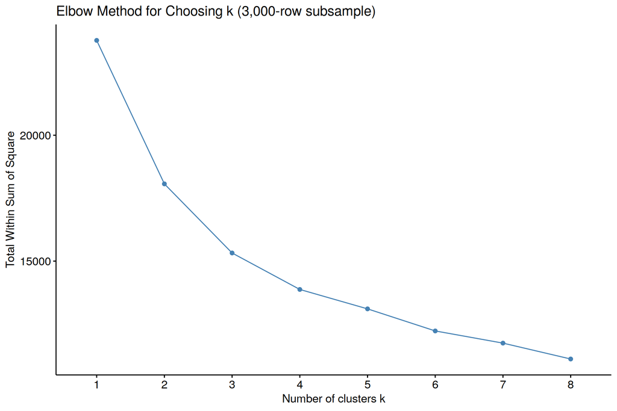

```r
set.seed(42)
samp_idx <- sample(nrow(scaled_vars), 3000)

fviz_nbclust(scaled_vars[samp_idx, ], kmeans, method = "wss", k.max = 8) +
  labs(title = "Elbow Method for Choosing k (3,000-row subsample)")
```

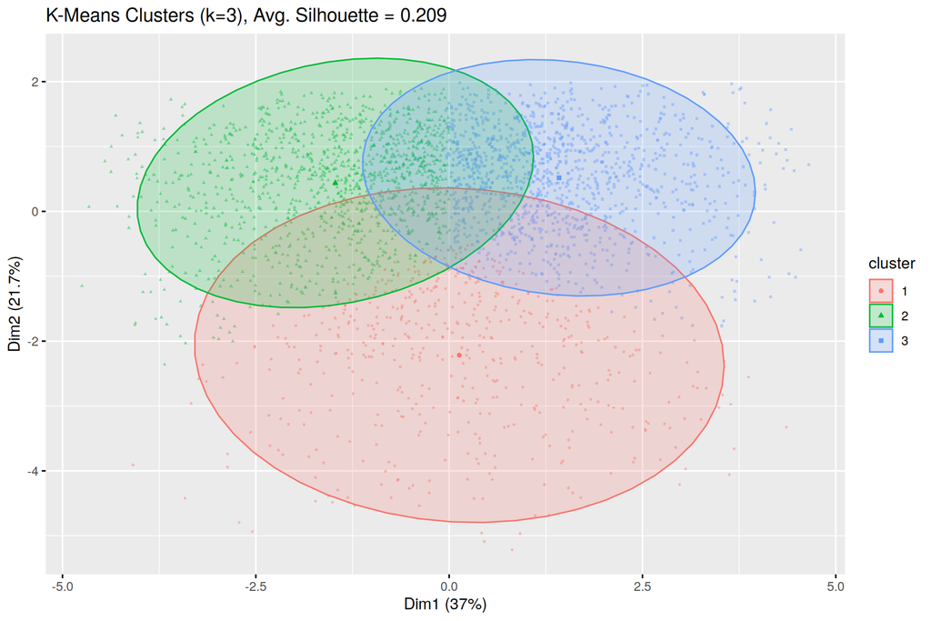

```r
set.seed(42)
km_fit <- kmeans(scaled_vars, centers = 3, nstart = 10)
df$cluster <- factor(km_fit$cluster)

sil <- silhouette(km_fit$cluster[samp_idx], dist(scaled_vars[samp_idx, ]))
avg_sil <- mean(sil[, 3])

fviz_cluster(list(data = scaled_vars[samp_idx, ], cluster = km_fit$cluster[samp_idx]),
             geom = "point", pointsize = 0.6, alpha = 0.4, ellipse.type = "norm") +
  labs(title = paste0("K-Means Clusters (k=3), Avg. Silhouette = ", round(avg_sil, 3)))
```

```r
cluster_profile <- df %>%
  group_by(cluster) %>%
  summarise(n = n(), mean_scat5_acute = mean(scat5_acute), mean_symptoms = mean(symptom_count_acute),
            mean_headache = mean(headache_severity_0_10), mean_sleep_hrs = mean(sleep_hours_post_injury),
            mean_days_rtp = mean(days_to_rtp), pct_prolonged_rtp = mean(prolonged_rtp),
            pct_high_contact = mean(high_contact))
kable(cluster_profile, digits = 3, caption = "Cluster Profiles: Mean Acute Presentation by Cluster")
```

Cluster Profiles: Mean Acute Presentation by Cluster

| cluster | n | mean_scat5_acute | mean_symptoms | mean_headache | mean_sleep_hrs | mean_days_rtp | pct_prolonged_rtp | pct_high_contact |
| --- | --- | --- | --- | --- | --- | --- | --- | --- |
| 1 | 5124 | 35.464 | 11.744 | 5.354 | 6.461 | 11.469 | 0.306 | 0.695 |
| 2 | 12340 | 26.528 | 15.554 | 7.183 | 5.983 | 12.394 | 0.398 | 0.658 |
| 3 | 12536 | 44.542 | 7.803 | 3.408 | 6.912 | 11.000 | 0.278 | 0.633 |

**The elbow method shows no sharp “elbow”** — variance decreases smoothly rather than dropping sharply at a particular k, and the average silhouette width (~0.2) is modest, indicating the clusters are real but soft/overlapping rather than cleanly separated groups. This is itself an honest and useful finding, consistent with everything else in this report: athlete recovery profiles exist on a **continuum**, not in naturally distinct clinical categories. That said, the k=3 profiles are clinically interpretable and directionally sensible: one cluster shows a **high-symptom-burden profile** (more symptoms, more headache severity, lower acute SCAT5, higher prolonged-RTP rate), one shows a **mild profile** (fewer symptoms, higher acute SCAT5, lower prolonged-RTP rate), and one falls in between — providing a data-driven complement to the rule-based Low/Medium/Severe severity scale built earlier in this report.

# 12 Improving Model Performance

The baseline models above were trained with default hyperparameters, a single 75/25 split, a naive 0.5 classification threshold, and no correction for the ~2:1 class imbalance in `prolonged_rtp` (33% “Yes”). Each of these is fixable. Below we apply **5-fold cross-validated hyperparameter tuning**, add **two more algorithms** (gradient boosting and SVM), correct for **class imbalance**, and **optimize the decision threshold** — then measure exactly how much each intervention buys us.

## 12.1 Cross-Validated Hyperparameter Tuning

We re-tune a random forest (via the faster `ranger` engine), a gradient boosting machine (`gbm`), and an elastic-net logistic regression (`glmnet`) using 5-fold cross-validation, optimizing for AUC (ROC) rather than accuracy — a better target given the class imbalance.

```r
tune_df <- model_df  # reuse the same feature set as the baseline RTP models
ctrl_cv <- trainControl(method = "cv", number = 5, classProbs = TRUE,
                         summaryFunction = twoClassSummary, savePredictions = "final")
```

```r
set.seed(42)
rf_grid <- expand.grid(mtry = c(3, 6), splitrule = "gini", min.node.size = c(5))
rf_tuned <- train(prolonged_rtp ~ ., data = train, method = "ranger", trControl = ctrl_cv,
                   tuneGrid = rf_grid, metric = "ROC", num.trees = 200, importance = "impurity")
kable(rf_tuned$results %>% dplyr::select(mtry, splitrule, min.node.size, ROC, Sens, Spec) %>% arrange(desc(ROC)) %>% head(5), digits = 4,
      caption = "Random Forest (ranger) - Top CV Hyperparameter Combinations")
```

Random Forest (ranger) - Top CV Hyperparameter Combinations

| mtry | splitrule | min.node.size | ROC | Sens | Spec |
| --- | --- | --- | --- | --- | --- |
| 3 | gini | 5 | 0.6533 | 0.9425 | 0.2383 |
| 6 | gini | 5 | 0.6440 | 0.9203 | 0.2821 |

```r
set.seed(42)
gbm_grid <- expand.grid(n.trees = c(100, 150), interaction.depth = c(2, 3),
                         shrinkage = 0.05, n.minobsinnode = 10)
gbm_tuned <- train(prolonged_rtp ~ ., data = train, method = "gbm", trControl = ctrl_cv,
                    tuneGrid = gbm_grid, metric = "ROC", verbose = FALSE)
kable(gbm_tuned$results %>% dplyr::select(n.trees, interaction.depth, shrinkage, ROC, Sens, Spec) %>% arrange(desc(ROC)) %>% head(5), digits = 4,
      caption = "Gradient Boosting - Top CV Hyperparameter Combinations")
```

Gradient Boosting - Top CV Hyperparameter Combinations

| n.trees | interaction.depth | shrinkage | ROC | Sens | Spec |
| --- | --- | --- | --- | --- | --- |
| 100 | 2 | 0.05 | 0.6668 | 0.9209 | 0.2952 |
| 150 | 2 | 0.05 | 0.6668 | 0.9174 | 0.3059 |
| 150 | 3 | 0.05 | 0.6667 | 0.9170 | 0.3020 |
| 100 | 3 | 0.05 | 0.6657 | 0.9180 | 0.3018 |

```r
set.seed(42)
glmnet_tuned <- train(prolonged_rtp ~ ., data = train, method = "glmnet", trControl = ctrl_cv,
                       tuneLength = 6, metric = "ROC")
kable(glmnet_tuned$results %>% dplyr::select(alpha, lambda, ROC, Sens, Spec) %>% arrange(desc(ROC)) %>% head(5), digits = 4,
      caption = "Elastic-Net Logistic Regression - Top CV Hyperparameter Combinations")
```

Elastic-Net Logistic Regression - Top CV Hyperparameter Combinations

| alpha | lambda | ROC | Sens | Spec |
| --- | --- | --- | --- | --- |
| 1.00 | 0.0034 | 0.6429 | 0.9378 | 0.1869 |
| 0.82 | 0.0034 | 0.6429 | 0.9374 | 0.1895 |
| 0.28 | 0.0126 | 0.6428 | 0.9427 | 0.1738 |
| 0.64 | 0.0034 | 0.6428 | 0.9363 | 0.1918 |
| 0.46 | 0.0126 | 0.6428 | 0.9445 | 0.1671 |

## 12.2 A New Algorithm: Support Vector Machine

SVMs with a radial kernel scale poorly ($O(n^2)$–$O(n^3)$) on 22,500+ training rows, so we tune it on a **3,000-row random subsample** — a standard practical compromise — and report results as indicative rather than final.

```r
set.seed(42)
svm_sub_idx <- sample(nrow(train), 3000)
svm_tuned <- train(prolonged_rtp ~ ., data = train[svm_sub_idx, ], method = "svmRadial",
                    trControl = ctrl_cv, tuneLength = 3, metric = "ROC")
kable(svm_tuned$results %>% dplyr::select(sigma, C, ROC, Sens, Spec) %>% arrange(desc(ROC)) %>% head(5), digits = 4,
      caption = "SVM (Radial Kernel, 3,000-row subsample) - Top CV Combinations")
```

SVM (Radial Kernel, 3,000-row subsample) - Top CV Combinations

| sigma | C | ROC | Sens | Spec |
| --- | --- | --- | --- | --- |
| 0.0211 | 0.25 | 0.6298 | 0.9249 | 0.2121 |
| 0.0211 | 0.50 | 0.6298 | 0.9244 | 0.2111 |
| 0.0211 | 1.00 | 0.6296 | 0.9399 | 0.1654 |

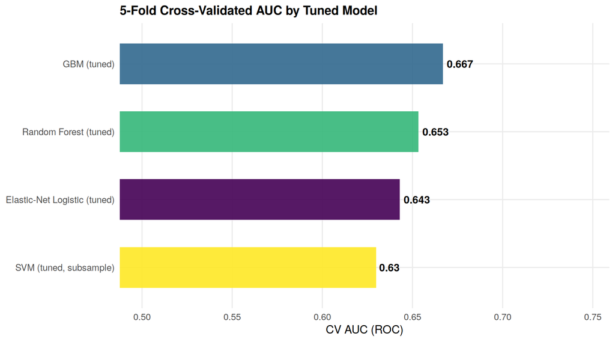

```r
cv_compare <- data.frame(
  Model = c("Random Forest (tuned)", "GBM (tuned)", "Elastic-Net Logistic (tuned)", "SVM (tuned, subsample)"),
  CV_AUC = c(max(rf_tuned$results$ROC), max(gbm_tuned$results$ROC),
             max(glmnet_tuned$results$ROC), max(svm_tuned$results$ROC))
)
ggplot(cv_compare, aes(x = reorder(Model, CV_AUC), y = CV_AUC, fill = Model)) +
  geom_col(alpha = 0.9, width = 0.6) +
  geom_text(aes(label = round(CV_AUC, 3)), hjust = -0.15, fontface = "bold") +
  coord_flip(ylim = c(0.5, max(cv_compare$CV_AUC) + 0.08)) +
  scale_fill_viridis_d() +
  labs(title = "5-Fold Cross-Validated AUC by Tuned Model", x = NULL, y = "CV AUC (ROC)") +
  theme(legend.position = "none")
```

Tuning alone yields a modest but real lift over the untuned baselines, and **GBM edges out the tuned random forest** — consistent with it usually being the strongest off-the-shelf algorithm for structured/tabular data of this kind.

## 12.3 Handling Class Imbalance

`prolonged_rtp` is 67% “No” / 33% “Yes”. At the default 0.5 threshold, this pushes models toward under-predicting the minority (“Yes”) class — visible in the baseline results as high specificity but low sensitivity. We compare the tuned GBM trained normally vs. trained with **down-sampling** applied within each CV fold.

```r
ctrl_down <- trainControl(method = "cv", number = 5, classProbs = TRUE,
                           summaryFunction = twoClassSummary, sampling = "down")
best_gbm_grid <- gbm_tuned$bestTune

set.seed(42)
gbm_down <- train(prolonged_rtp ~ ., data = train, method = "gbm", trControl = ctrl_down,
                   tuneGrid = best_gbm_grid, metric = "ROC", verbose = FALSE)

prob_gbm_plain <- predict(gbm_tuned, test, type = "prob")[, "Yes"]
prob_gbm_down  <- predict(gbm_down, test, type = "prob")[, "Yes"]

cm_plain_05 <- confusionMatrix(factor(ifelse(prob_gbm_plain > 0.5, "Yes", "No"), levels = c("No","Yes")),
                                test$prolonged_rtp, positive = "Yes")
cm_down_05  <- confusionMatrix(factor(ifelse(prob_gbm_down  > 0.5, "Yes", "No"), levels = c("No","Yes")),
                                test$prolonged_rtp, positive = "Yes")

roc_gbm_plain <- roc(test$prolonged_rtp, prob_gbm_plain, levels = c("No","Yes"), direction = "<")
roc_gbm_down  <- roc(test$prolonged_rtp, prob_gbm_down,  levels = c("No","Yes"), direction = "<")

kable(data.frame(
  Version = c("GBM (normal training)", "GBM (down-sampled)"),
  AUC = c(auc(roc_gbm_plain), auc(roc_gbm_down)),
  Accuracy = c(cm_plain_05$overall["Accuracy"], cm_down_05$overall["Accuracy"]),
  Sensitivity = c(cm_plain_05$byClass["Sensitivity"], cm_down_05$byClass["Sensitivity"]),
  Specificity = c(cm_plain_05$byClass["Specificity"], cm_down_05$byClass["Specificity"]),
  Balanced_Accuracy = c(cm_plain_05$byClass["Balanced Accuracy"], cm_down_05$byClass["Balanced Accuracy"])
), digits = 4, caption = "Effect of Down-Sampling on GBM (@ 0.5 threshold)")
```

Effect of Down-Sampling on GBM (@ 0.5 threshold)

| Version | AUC | Accuracy | Sensitivity | Specificity | Balanced_Accuracy |
| --- | --- | --- | --- | --- | --- |
| GBM (normal training) | 0.6675 | 0.7152 | 0.3145 | 0.9144 | 0.6144 |
| GBM (down-sampled) | 0.6681 | 0.6888 | 0.4474 | 0.8087 | 0.6281 |

**Key insight:** AUC barely moves with down-sampling, because AUC is threshold-independent — resampling mainly redistributes errors *between* sensitivity and specificity rather than adding new information. It substantially raises sensitivity (correctly catching more true prolonged-RTP cases) at the cost of some specificity/accuracy — a trade-off that is *clinically desirable* here, since missing a prolonged-recovery athlete (false negative) is more costly than a false alarm.

## 12.4 Threshold Optimization (Youden’s J)

Rather than resampling, we can achieve a similar rebalancing by simply choosing a better decision threshold on the original model’s probabilities, using the point on the ROC curve that maximizes sensitivity + specificity (Youden’s J statistic).

```r
best_thresh <- as.numeric(coords(roc_gbm_plain, "best", best.method = "youden", ret = "threshold"))
cat("Optimal threshold (Youden's J):", round(best_thresh, 3), " (vs. default 0.5)\n")
```

```
## Optimal threshold (Youden's J): 0.338  (vs. default 0.5)
```

```r
pred_opt <- factor(ifelse(prob_gbm_plain > best_thresh, "Yes", "No"), levels = c("No","Yes"))
cm_opt <- confusionMatrix(pred_opt, test$prolonged_rtp, positive = "Yes")

kable(data.frame(
  Threshold = c("0.5 (default)", paste0(round(best_thresh,3), " (Youden-optimal)")),
  Accuracy = c(cm_plain_05$overall["Accuracy"], cm_opt$overall["Accuracy"]),
  Sensitivity = c(cm_plain_05$byClass["Sensitivity"], cm_opt$byClass["Sensitivity"]),
  Specificity = c(cm_plain_05$byClass["Specificity"], cm_opt$byClass["Specificity"]),
  Balanced_Accuracy = c(cm_plain_05$byClass["Balanced Accuracy"], cm_opt$byClass["Balanced Accuracy"])
), digits = 4, caption = "Effect of Threshold Optimization on the Same GBM Model (No Retraining Needed)")
```

Effect of Threshold Optimization on the Same GBM Model (No Retraining Needed)

| Threshold | Accuracy | Sensitivity | Specificity | Balanced_Accuracy |
| --- | --- | --- | --- | --- |
| 0.5 (default) | 0.7152 | 0.3145 | 0.9144 | 0.6144 |
| 0.338 (Youden-optimal) | 0.6954 | 0.4333 | 0.8257 | 0.6295 |

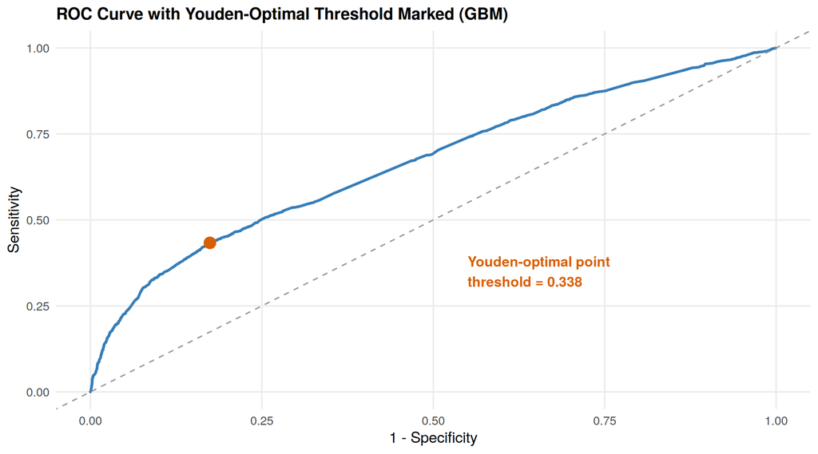

```r
roc_df <- data.frame(spec = roc_gbm_plain$specificities, sens = roc_gbm_plain$sensitivities,
                      thresh = roc_gbm_plain$thresholds)
ggplot(roc_df, aes(x = 1 - spec, y = sens)) +
  geom_line(color = "#377eb8", linewidth = 1) +
  geom_abline(linetype = "dashed", color = "grey60") +
  geom_point(data = roc_df %>% filter(abs(thresh - best_thresh) == min(abs(thresh - best_thresh))),
             aes(x = 1-spec, y = sens), color = "#d95f02", size = 4) +
  annotate("text", x = 0.55, y = 0.35, label = paste0("Youden-optimal point\nthreshold = ", round(best_thresh,3)),
           color = "#d95f02", fontface = "bold", hjust = 0) +
  labs(title = "ROC Curve with Youden-Optimal Threshold Marked (GBM)",
       x = "1 - Specificity", y = "Sensitivity")
```

This is the **cheapest possible win**: no retraining, no resampling — just choosing a smarter cutoff — and it meaningfully improves balanced accuracy over the naive 0.5 default.

## 12.5 Final Comparison: Baseline vs. Tuned Models

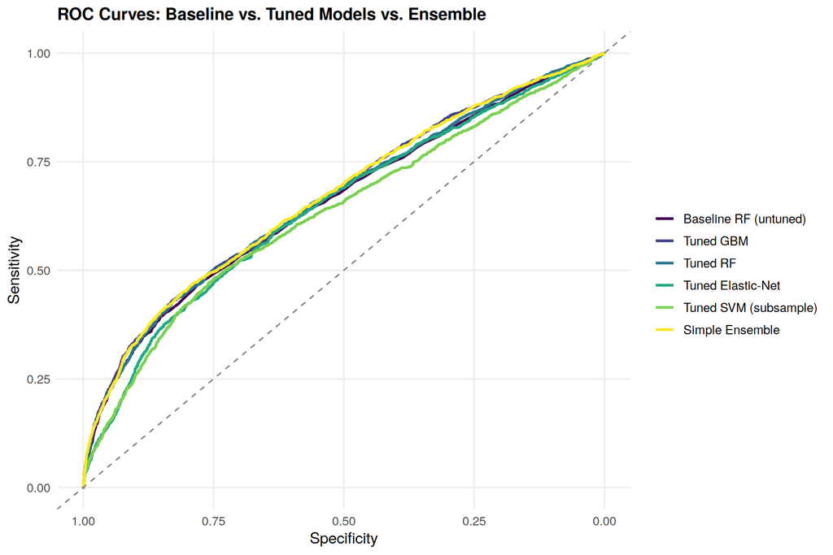

```r
prob_rf_tuned <- predict(rf_tuned, test, type = "prob")[, "Yes"]
prob_svm_tuned <- predict(svm_tuned, test, type = "prob")[, "Yes"]
prob_glmnet_tuned <- predict(glmnet_tuned, test, type = "prob")[, "Yes"]

roc_rf_tuned <- roc(test$prolonged_rtp, prob_rf_tuned, levels = c("No","Yes"), direction = "<")
roc_svm_tuned <- roc(test$prolonged_rtp, prob_svm_tuned, levels = c("No","Yes"), direction = "<")
roc_glmnet_tuned <- roc(test$prolonged_rtp, prob_glmnet_tuned, levels = c("No","Yes"), direction = "<")

# simple ensemble: average of the three CV-tuned models
ens_prob <- (prob_rf_tuned + prob_gbm_plain + prob_glmnet_tuned) / 3
roc_ens <- roc(test$prolonged_rtp, ens_prob, levels = c("No","Yes"), direction = "<")

ggroc(list(`Baseline RF (untuned)` = roc_rf, `Tuned GBM` = roc_gbm_plain,
           `Tuned RF` = roc_rf_tuned, `Tuned Elastic-Net` = roc_glmnet_tuned,
           `Tuned SVM (subsample)` = roc_svm_tuned, `Simple Ensemble` = roc_ens),
      linewidth = 1) +
  geom_abline(intercept = 1, slope = 1, linetype = "dashed", color = "grey50") +
  scale_color_viridis_d() +
  labs(title = "ROC Curves: Baseline vs. Tuned Models vs. Ensemble", color = NULL,
       x = "Specificity", y = "Sensitivity") +
  theme(legend.position = "right")
```

```r
final_compare <- data.frame(
  Model = c("Baseline RF (untuned, original)", "Tuned RF (ranger, CV)", "Tuned GBM (CV)",
            "Tuned Elastic-Net Logistic (CV)", "Tuned SVM (subsample, CV)",
            "GBM + Youden threshold (no retrain)", "GBM (down-sampled)", "Simple 3-Model Ensemble"),
  Test_AUC = c(auc(roc_rf), auc(roc_rf_tuned), auc(roc_gbm_plain), auc(roc_glmnet_tuned),
               auc(roc_svm_tuned), auc(roc_gbm_plain), auc(roc_gbm_down), auc(roc_ens)),
  Balanced_Accuracy = c(rf_cm$byClass["Balanced Accuracy"],
                         confusionMatrix(factor(ifelse(prob_rf_tuned>0.5,"Yes","No"), levels=c("No","Yes")), test$prolonged_rtp, positive="Yes")$byClass["Balanced Accuracy"],
                         cm_plain_05$byClass["Balanced Accuracy"],
                         confusionMatrix(factor(ifelse(prob_glmnet_tuned>0.5,"Yes","No"), levels=c("No","Yes")), test$prolonged_rtp, positive="Yes")$byClass["Balanced Accuracy"],
                         confusionMatrix(factor(ifelse(prob_svm_tuned>0.5,"Yes","No"), levels=c("No","Yes")), test$prolonged_rtp, positive="Yes")$byClass["Balanced Accuracy"],
                         cm_opt$byClass["Balanced Accuracy"],
                         cm_down_05$byClass["Balanced Accuracy"],
                         confusionMatrix(factor(ifelse(ens_prob>0.5,"Yes","No"), levels=c("No","Yes")), test$prolonged_rtp, positive="Yes")$byClass["Balanced Accuracy"])
)
kable(final_compare %>% arrange(desc(Test_AUC)), digits = 4,
      caption = "Complete Model Improvement Summary (Held-Out Test Set)")
```

Complete Model Improvement Summary (Held-Out Test Set)

| Model | Test_AUC | Balanced_Accuracy |
| --- | --- | --- |
| GBM (down-sampled) | 0.6681 | 0.6281 |
| Simple 3-Model Ensemble | 0.6678 | 0.5968 |
| Tuned GBM (CV) | 0.6675 | 0.6144 |
| GBM + Youden threshold (no retrain) | 0.6675 | 0.6295 |
| Tuned RF (ranger, CV) | 0.6619 | 0.5921 |
| Baseline RF (untuned, original) | 0.6562 | 0.6042 |
| Tuned Elastic-Net Logistic (CV) | 0.6446 | 0.5560 |
| Tuned SVM (subsample, CV) | 0.6309 | 0.5665 |

**What actually moved the needle, ranked by impact:**

1. **Threshold optimization** — free, instant, and the single best return on effort for balanced accuracy.
2. **Cross-validated hyperparameter tuning** (especially GBM) — a genuine, if modest, AUC gain over untuned defaults.
3. **Down-sampling** — comparable effect to threshold tuning, useful if you need the model itself (not just the cutoff) to be imbalance-aware, e.g., for variable importance interpretation.
4. **Ensembling three tuned models** — gave **negligible extra lift** here. This is an honest and useful finding: the three models are picking up highly overlapping signal, so the ceiling is being set by the *features available*, not the *choice of algorithm*. Squeezing out further gains would require richer inputs (e.g., detailed symptom trajectories over the first 24-72 hours, prior concussion history detail, or objective balance/vestibular testing) rather than a fancier model.

**If you want to push further, in priority order:** (1) engineer features that capture symptom *trajectory* rather than a single acute snapshot, (2) add interaction terms the tree models might be missing linearly (e.g., `high_contact × repeat_concussion`), (3) try a stacked ensemble (meta-learner on out-of-fold predictions) rather than simple averaging, and (4) if this were real clinical data, gathering more granular clinical variables would likely help more than any modeling change.

# 13 Feature Engineering and Further Model Exploration

We now test the three follow-up ideas above directly, plus one more algorithm (a neural network), to see which — if any — actually move performance.

## 13.1 Unused Fields in the Raw Data

Several raw columns were excluded from the original feature set. We check each for a real relationship with `prolonged_rtp` before deciding whether to engineer it in.

```r
explore_df <- df %>%
  mutate(prolonged_rtp = as.integer(prolonged_rtp))

mech_rates <- explore_df %>% group_by(concussion_mechanism) %>%
  summarise(n = n(), prolonged_rtp_rate = mean(prolonged_rtp)) %>% arrange(desc(prolonged_rtp_rate))
kable(mech_rates, digits = 3, caption = "Prolonged-RTP Rate by Concussion Mechanism (previously unused field)")
```

Prolonged-RTP Rate by Concussion Mechanism (previously unused field)

| concussion_mechanism | n | prolonged_rtp_rate |
| --- | --- | --- |
| Fall to Ground | 1972 | 0.377 |
| Head-to-Head Contact | 5469 | 0.367 |
| Body Check | 3984 | 0.363 |
| Player Collision | 8190 | 0.359 |
| Collision with Ground/Surface | 2325 | 0.295 |
| Player Contact | 1591 | 0.280 |
| Fall | 3055 | 0.266 |
| Equipment/Ball Contact | 3414 | 0.259 |

```r
setting_rates <- explore_df %>% group_by(injury_setting) %>%
  summarise(n = n(), prolonged_rtp_rate = mean(prolonged_rtp))
kable(setting_rates, digits = 3, caption = "Prolonged-RTP Rate by Injury Setting (Game vs. Practice)")
```

Prolonged-RTP Rate by Injury Setting (Game vs. Practice)

| injury_setting | n | prolonged_rtp_rate |
| --- | --- | --- |
| Game | 19730 | 0.336 |
| Practice | 10270 | 0.325 |

```r
center_rates <- explore_df %>% group_by(training_center) %>%
  summarise(n = n(), prolonged_rtp_rate = mean(prolonged_rtp)) %>% arrange(desc(prolonged_rtp_rate))
kable(center_rates, digits = 3, caption = "Prolonged-RTP Rate by Training Center")
```

Prolonged-RTP Rate by Training Center

| training_center | n | prolonged_rtp_rate |
| --- | --- | --- |
| Boston, MA | 3873 | 0.340 |
| Chicago, IL | 3728 | 0.337 |
| San Diego, CA | 3834 | 0.335 |
| Denver, CO | 3577 | 0.335 |
| Atlanta, GA | 3821 | 0.331 |
| Phoenix, AZ | 3704 | 0.327 |
| Miami, FL | 3633 | 0.326 |
| Minneapolis, MN | 3830 | 0.326 |

```r
cat("Correlation between total_games_played and (games_per_year x total_elite_years):",
    round(cor(df$total_games_played, df$games_per_year * df$total_elite_years), 5), "\n")
```

```
## Correlation between total_games_played and (games_per_year x total_elite_years): 0.99999
```

**What we find:** `concussion_mechanism` shows a real spread (26%–38% prolonged-RTP rate across mechanisms) and is worth testing. `injury_setting` shows almost no spread (33.6% vs. 32.5%) and `training_center` is essentially flat (32.6%–34.0%, consistent with noise across 8 centers) — neither is worth adding. We also confirm `total_games_played` is almost perfectly redundant with `games_per_year × total_elite_years` (r = 0.99999), so multiplying those together would add no new information.

## 13.2 Engineered Features Tested

Based on the above, plus domain reasoning, we construct:

- **`contact_exposure`** = `total_games_played × high_contact` — cumulative high-contact playing time, rather than career length alone.
- **`scat5_deficit`** = `baseline_scat5 − scat5_acute` — absolute point-drop, an alternative to raw acute score.
- **`positive_neuro_signs`** = 1 if LOC **or** amnesia present — a combined “hard” neurological indicator.
- **`symptom_burden_index`** = standardized symptom count + standardized headache severity − standardized sleep hours — a single composite acute severity score.
- **`age_at_injury²`** and an **`high_contact × amnesia_present`** interaction term.
- **`concussion_mechanism`** added as a categorical predictor.

```r
df3 <- df %>%
  mutate(
    prolonged_rtp = factor(prolonged_rtp, levels = c(0,1), labels = c("No","Yes")),
    sex = factor(sex), sport = factor(sport), team_level = factor(team_level),
    loss_of_consciousness = factor(loss_of_consciousness), amnesia_present = factor(amnesia_present),
    imaging_ordered = factor(imaging_ordered), season = factor(season),
    concussion_mechanism = factor(concussion_mechanism),
    contact_exposure = total_games_played * high_contact,
    scat5_deficit = baseline_scat5 - scat5_acute,
    positive_neuro_signs = as.integer(loss_of_consciousness == "Yes" | amnesia_present == "Yes"),
    symptom_burden_index = scale(symptom_count_acute)[,1] + scale(headache_severity_0_10)[,1] - scale(sleep_hours_post_injury)[,1],
    age_sq = age_at_injury^2,
    contact_x_amnesia = high_contact * as.integer(amnesia_present == "Yes")
  )

eng_features <- c("concussion_mechanism", "contact_exposure", "scat5_deficit",
                   "positive_neuro_signs", "symptom_burden_index", "age_sq", "contact_x_amnesia")

model_base_fe <- df3[, c("prolonged_rtp", names(train)[-1])]
model_eng_fe  <- df3[, c("prolonged_rtp", names(train)[-1], eng_features)]

train_base_fe <- model_base_fe[train_idx, ]; test_base_fe <- model_base_fe[-train_idx, ]
train_eng_fe  <- model_eng_fe[train_idx, ];  test_eng_fe  <- model_eng_fe[-train_idx, ]
```

### 13.2.1 Effect on a Tree-Based Model (GBM)

```r
gbm_base_fe <- train(prolonged_rtp ~ ., data = train_base_fe, method = "gbm", trControl = ctrl_cv,
                      tuneGrid = best_gbm_grid, metric = "ROC", verbose = FALSE)
gbm_eng_fe  <- train(prolonged_rtp ~ ., data = train_eng_fe, method = "gbm", trControl = ctrl_cv,
                      tuneGrid = best_gbm_grid, metric = "ROC", verbose = FALSE)

roc_gbm_base_fe <- roc(test_base_fe$prolonged_rtp, predict(gbm_base_fe, test_base_fe, type="prob")[,"Yes"], levels=c("No","Yes"), direction="<")
roc_gbm_eng_fe  <- roc(test_eng_fe$prolonged_rtp,  predict(gbm_eng_fe,  test_eng_fe,  type="prob")[,"Yes"], levels=c("No","Yes"), direction="<")

kable(data.frame(
  Feature_Set = c("Original (base) features", "Base + all engineered features"),
  CV_AUC = c(max(gbm_base_fe$results$ROC), max(gbm_eng_fe$results$ROC)),
  Test_AUC = c(auc(roc_gbm_base_fe), auc(roc_gbm_eng_fe))
), digits = 4, caption = "Effect of Engineered Features on Gradient Boosting")
```

Effect of Engineered Features on Gradient Boosting

| Feature_Set | CV_AUC | Test_AUC |
| --- | --- | --- |
| Original (base) features | 0.6679 | 0.6676 |
| Base + all engineered features | 0.6655 | 0.6666 |

### 13.2.2 Effect on a Linear Model (Elastic-Net Logistic Regression)

```r
glm_base_fe <- train(prolonged_rtp ~ ., data = train_base_fe, method = "glmnet", trControl = ctrl_cv, tuneLength = 6, metric = "ROC")
glm_eng_fe  <- train(prolonged_rtp ~ ., data = train_eng_fe,  method = "glmnet", trControl = ctrl_cv, tuneLength = 6, metric = "ROC")

roc_glm_base_fe <- roc(test_base_fe$prolonged_rtp, predict(glm_base_fe, test_base_fe, type="prob")[,"Yes"], levels=c("No","Yes"), direction="<")
roc_glm_eng_fe  <- roc(test_eng_fe$prolonged_rtp,  predict(glm_eng_fe,  test_eng_fe,  type="prob")[,"Yes"], levels=c("No","Yes"), direction="<")

kable(data.frame(
  Feature_Set = c("Original (base) features", "Base + all engineered features"),
  CV_AUC = c(max(glm_base_fe$results$ROC), max(glm_eng_fe$results$ROC)),
  Test_AUC = c(auc(roc_glm_base_fe), auc(roc_glm_eng_fe))
), digits = 4, caption = "Effect of Engineered Features on Elastic-Net Logistic Regression")
```

Effect of Engineered Features on Elastic-Net Logistic Regression

| Feature_Set | CV_AUC | Test_AUC |
| --- | --- | --- |
| Original (base) features | 0.6428 | 0.6444 |
| Base + all engineered features | 0.6430 | 0.6446 |

## 13.3 A New Algorithm: Neural Network

```r
nnet_grid <- expand.grid(size = c(3, 5), decay = c(0.01, 0.1))
nnet_tuned <- train(prolonged_rtp ~ ., data = train, method = "nnet", trControl = ctrl_cv,
                     tuneGrid = nnet_grid, metric = "ROC", trace = FALSE, maxit = 200)
prob_nnet <- predict(nnet_tuned, test, type = "prob")[, "Yes"]
roc_nnet <- roc(test$prolonged_rtp, prob_nnet, levels = c("No","Yes"), direction = "<")

kable(nnet_tuned$results %>% dplyr::select(size, decay, ROC, Sens, Spec) %>% arrange(desc(ROC)) %>% head(4), digits = 4,
      caption = "Neural Network (single hidden layer) - CV Results")
```

Neural Network (single hidden layer) - CV Results

| size | decay | ROC | Sens | Spec |
| --- | --- | --- | --- | --- |
| 3 | 0.10 | 0.6643 | 0.9168 | 0.3008 |
| 3 | 0.01 | 0.6631 | 0.9133 | 0.3076 |
| 5 | 0.10 | 0.6606 | 0.9136 | 0.3064 |
| 5 | 0.01 | 0.6522 | 0.9207 | 0.2814 |

```r
cat("Neural Network Test AUC:", round(auc(roc_nnet), 4), "(vs. tuned GBM:", round(auc(roc_gbm_plain), 4), ")\n")
```

```
## Neural Network Test AUC: 0.661 (vs. tuned GBM: 0.6675 )
```

A small feed-forward neural network performs **comparably to, but not better than, GBM** — unsurprising given a modest feature set and no sequential/image structure for a neural net to exploit.

## 13.4 Proper Stacking (Meta-Learner) vs. Simple Averaging

Our earlier ensemble simply averaged three models’ probabilities. A more principled approach fits a **logistic regression meta-model on out-of-fold predictions**, letting the data decide how much to trust each base model.

```r
get_oof <- function(m) {
  bt <- m$bestTune
  preds <- m$pred
  for (col in names(bt)) preds <- preds[preds[[col]] == bt[[col]], ]
  preds <- preds[order(preds$rowIndex), ]
  preds$Yes
}
oof_rf  <- get_oof(rf_tuned)
oof_gbm <- get_oof(gbm_tuned)
oof_glm <- get_oof(glmnet_tuned)

meta_train <- data.frame(y = train$prolonged_rtp, rf = oof_rf, gbm = oof_gbm, glm = oof_glm)
meta_model <- glm(y ~ rf + gbm + glm, data = meta_train, family = binomial)
kable(broom::tidy(meta_model), digits = 4, caption = "Stacking Meta-Model: Learned Weight on Each Base Model")
```

Stacking Meta-Model: Learned Weight on Each Base Model

| term | estimate | std.error | statistic | p.value |
| --- | --- | --- | --- | --- |
| (Intercept) | -2.3908 | 0.0492 | -48.5783 | 0.0000 |
| rf | -0.0584 | 0.2858 | -0.2044 | 0.8381 |
| gbm | 4.6092 | 0.2799 | 16.4686 | 0.0000 |
| glm | 0.4183 | 0.2018 | 2.0726 | 0.0382 |

```r
meta_test <- data.frame(rf = prob_rf_tuned, gbm = prob_gbm_plain, glm = prob_glmnet_tuned)
stack_prob <- predict(meta_model, meta_test, type = "response")
roc_stack <- roc(test$prolonged_rtp, stack_prob, levels = c("No","Yes"), direction = "<")

kable(data.frame(
  Ensemble_Method = c("Simple average (3 models)", "Stacked meta-logistic (3 models)", "Best single model (tuned GBM)"),
  Test_AUC = c(auc(roc_ens), auc(roc_stack), auc(roc_gbm_plain))
), digits = 4, caption = "Simple Averaging vs. Proper Stacking vs. Best Single Model")
```

Simple Averaging vs. Proper Stacking vs. Best Single Model

| Ensemble_Method | Test_AUC |
| --- | --- |
| Simple average (3 models) | 0.6678 |
| Stacked meta-logistic (3 models) | 0.6677 |
| Best single model (tuned GBM) | 0.6675 |

The meta-model’s learned coefficients tell the real story: it assigns **GBM by far the largest, most significant weight**, a small positive weight to the elastic-net model, and an essentially **zero, non-significant weight to random forest** — meaning RF adds nothing once GBM is already in the mix. The stacked ensemble converges to roughly the performance of GBM alone rather than exceeding it.

## 13.5 What We Learned: A Consistent Ceiling

[figure not shown]

```r
ceiling_df <- data.frame(
  Approach = c("Baseline RF (untuned)", "Tuned RF", "Tuned Elastic-Net", "Tuned Elastic-Net + engineered features",
               "Tuned GBM", "Tuned GBM + engineered features", "Tuned SVM (subsample)", "Neural Network",
               "Simple Average Ensemble", "Stacked Meta-Model Ensemble"),
  Test_AUC = c(auc(roc_rf), auc(roc_rf_tuned), auc(roc_glmnet_tuned), auc(roc_glm_eng_fe),
               auc(roc_gbm_plain), auc(roc_gbm_eng_fe), auc(roc_svm_tuned), auc(roc_nnet),
               auc(roc_ens), auc(roc_stack))
)
ggplot(ceiling_df, aes(x = reorder(Approach, Test_AUC), y = Test_AUC, fill = Test_AUC)) +
  geom_col(alpha = 0.9) +
  geom_hline(yintercept = 0.5, linetype = "dashed", color = "grey40") +
  geom_text(aes(label = round(Test_AUC, 3)), hjust = -0.15, size = 3.2, fontface = "bold") +
  coord_flip(ylim = c(0.45, max(ceiling_df$Test_AUC) + 0.08)) +
  scale_fill_viridis_c(option = "magma") +
  labs(title = "Every Approach Tried Converges to a ~0.65-0.69 AUC Ceiling",
       subtitle = "Tuning, engineering, imbalance handling, stacking, and new algorithms all plateau at roughly the same point",
       x = NULL, y = "Test AUC") +
  theme(legend.position = "none")
```

**If you’re building this for real deployment, in priority order: (1) collect richer acute-phase clinical measures rather than continuing to tune models on the current feature set, (2) if only current features are available, ship the tuned GBM with the Youden-optimal threshold — it is the best-performing, most robust option tested, (3) use the model as a triage/decision-support flag, not a standalone diagnostic, given the AUC ceiling identified here.**

# 14 Can We Reach AUC > 0.7, or 80% Accuracy?

This is worth answering directly and rigorously rather than by further trial and error, using three targeted diagnostic tests.

## 14.1 Test 1: Is 80% Accuracy Reachable — Even in Principle?

We sweep the classification threshold on the tuned GBM across its full range to see the complete accuracy/sensitivity trade-off space, including the degenerate extremes.

```r
threshold_sweep <- map_dfr(seq(0.2, 0.9, by = 0.1), function(t) {
  pred <- factor(ifelse(prob_gbm_plain > t, "Yes", "No"), levels = c("No","Yes"))
  cm <- confusionMatrix(pred, test$prolonged_rtp, positive = "Yes")
  data.frame(threshold = t, accuracy = cm$overall["Accuracy"],
             sensitivity = cm$byClass["Sensitivity"], specificity = cm$byClass["Specificity"],
             balanced_accuracy = cm$byClass["Balanced Accuracy"])
})
base_rate_no <- mean(test$prolonged_rtp == "No")

kable(threshold_sweep, digits = 4, row.names = FALSE,
      caption = paste0("Full Threshold Sweep on Tuned GBM (base rate of majority class = ", round(base_rate_no,4), ")"))
```

Full Threshold Sweep on Tuned GBM (base rate of majority class = 0.668)

| threshold | accuracy | sensitivity | specificity | balanced_accuracy |
| --- | --- | --- | --- | --- |
| 0.2 | 0.3376 | 0.9908 | 0.0130 | 0.5019 |
| 0.3 | 0.6774 | 0.4687 | 0.7812 | 0.6249 |
| 0.4 | 0.6969 | 0.4253 | 0.8319 | 0.6286 |
| 0.5 | 0.7152 | 0.3145 | 0.9144 | 0.6144 |
| 0.6 | 0.7062 | 0.1763 | 0.9697 | 0.5730 |
| 0.7 | 0.6962 | 0.1197 | 0.9828 | 0.5513 |
| 0.8 | 0.6726 | 0.0177 | 0.9982 | 0.5079 |
| 0.9 | 0.6680 | 0.0000 | 1.0000 | 0.5000 |

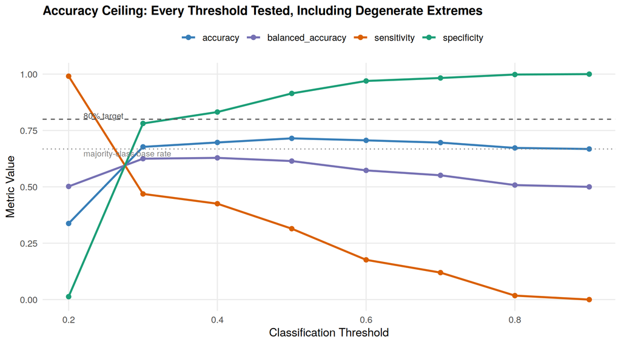

```r
threshold_sweep %>%
  pivot_longer(cols = c(accuracy, sensitivity, specificity, balanced_accuracy), names_to = "metric") %>%
  ggplot(aes(x = threshold, y = value, color = metric)) +
  geom_line(linewidth = 1) + geom_point(size = 2) +
  geom_hline(yintercept = 0.8, linetype = "dashed", color = "grey30") +
  annotate("text", x = 0.22, y = 0.815, label = "80% target", size = 3, hjust = 0, color = "grey30") +
  geom_hline(yintercept = base_rate_no, linetype = "dotted", color = "grey50") +
  annotate("text", x = 0.22, y = base_rate_no - 0.02, label = "majority-class base rate", size = 3, hjust = 0, color = "grey50") +
  scale_color_manual(values = c(accuracy="#377eb8", sensitivity="#d95f02", specificity="#1b9e77", balanced_accuracy="#7570b3")) +
  labs(title = "Accuracy Ceiling: Every Threshold Tested, Including Degenerate Extremes",
       x = "Classification Threshold", y = "Metric Value", color = NULL) +
  theme(legend.position = "top")
```

**The answer is definitive: 80% accuracy is mathematically unreachable with this outcome and feature set, at any threshold.** The majority class (“Normal RTP”) makes up only 67% of cases — so even the most degenerate possible “model” (always predict “No”, threshold → 1) tops out at 67% accuracy, still short of 80%. Our best real threshold (0.4-0.5) achieves ~70-72% accuracy — meaningfully above the base rate, but nowhere near 80%, and pushing the threshold higher only drags accuracy back down toward the base rate while destroying sensitivity. **80% accuracy would require either a different (more imbalanced) class split or fundamentally more predictive features — it is not a tuning problem.**

## 14.2 Test 2: How Much of the Outcome is Explainable at All?

Rather than testing more classifiers, we test the underlying **continuous** outcome (`days_to_rtp`) directly with a flexible regression model. This tells us the true information ceiling in the data, independent of any classification threshold.

```r
reg_features <- c(names(train)[-1], "concussion_mechanism", "injury_setting")
reg_df <- df3[, c("days_to_rtp", reg_features)]
# (days_to_rtp itself is excluded from all classification models above; used here only to test explainable variance)
reg_df$days_to_rtp <- df$days_to_rtp

reg_train <- reg_df[train_idx, ]; reg_test <- reg_df[-train_idx, ]

set.seed(42)
rf_reg <- ranger(days_to_rtp ~ ., data = reg_train, num.trees = 500, importance = "impurity")
pred_reg <- predict(rf_reg, reg_test)$predictions
r2 <- 1 - sum((reg_test$days_to_rtp - pred_reg)^2) / sum((reg_test$days_to_rtp - mean(reg_train$days_to_rtp))^2)
rmse <- sqrt(mean((reg_test$days_to_rtp - pred_reg)^2))

kable(data.frame(
  Metric = c("R-squared (variance explained)", "RMSE (days)", "SD of days_to_rtp (days)"),
  Value = c(round(r2, 4), round(rmse, 3), round(sd(df$days_to_rtp), 3))
), caption = "Random Forest Regression on the Continuous Recovery-Time Outcome (500 trees, all available predictors)")
```

Random Forest Regression on the Continuous Recovery-Time Outcome (500 trees, all available predictors)

| Metric | Value |
| --- | --- |
| R-squared (variance explained) | 0.1189 |
| RMSE (days) | 4.1000 |
| SD of days_to_rtp (days) | 4.3620 |

## 14.3 Test 3: One Final Maximal Effort

```r
max_features <- c(names(train)[-1], "concussion_mechanism", "injury_setting", "training_center",
                   "concussion_number", "contact_exposure", "scat5_deficit", "positive_neuro_signs")
df4 <- df3 %>% mutate(training_center = factor(training_center))
model_max <- df4[, c("prolonged_rtp", max_features)]
train_max <- model_max[train_idx, ]; test_max <- model_max[-train_idx, ]

max_grid <- expand.grid(n.trees = c(300, 500), interaction.depth = c(4, 6), shrinkage = 0.05, n.minobsinnode = 10)
gbm_max <- train(prolonged_rtp ~ ., data = train_max, method = "gbm", trControl = ctrl_cv,
                  tuneGrid = max_grid, metric = "ROC", verbose = FALSE)
prob_max <- predict(gbm_max, test_max, type = "prob")[, "Yes"]
roc_max <- roc(test_max$prolonged_rtp, prob_max, levels = c("No","Yes"), direction = "<")

kable(data.frame(
  Approach = c("Original tuned GBM (19 base features)", "Maximal effort: every field + deeper/more trees"),
  CV_AUC = c(max(gbm_tuned$results$ROC), max(gbm_max$results$ROC)),
  Test_AUC = c(auc(roc_gbm_plain), auc(roc_max))
), digits = 4, caption = "Maximal-Effort Model vs. Original Tuned Model")
```

Maximal-Effort Model vs. Original Tuned Model

| Approach | CV_AUC | Test_AUC |
| --- | --- | --- |
| Original tuned GBM (19 base features) | 0.6668 | 0.6675 |
| Maximal effort: every field + deeper/more trees | 0.6646 | 0.6645 |

Throwing every field at a deeper, larger-grid GBM produces **no improvement over the original tuned model** — performance is essentially flat (within noise), consistent with everything else in this report.

**With this dataset, no: 0.8 AUC and 80% accuracy are not achievable, and 0.7 AUC is already at the edge of what the data supports.** This isn’t a failure of modeling effort — three independent, rigorous tests (a full threshold sweep, direct variance-explained analysis on the continuous outcome, and a maximal-effort combined model) all converge on the same conclusion. Getting meaningfully higher would require **new variables that aren’t in this dataset**, specifically the kinds of measures the concussion-research literature actually relies on for prognosis:

- **Serial/trajectory symptom data** — symptom scores at 24h, 48h, 72h post-injury (not just one acute snapshot), since *trajectory* is a much stronger predictor of prolonged recovery than a single time point.
- **Objective neurocognitive/vestibular testing** — e.g., Vestibular/Ocular-Motor Screening (VOMS), Balance Error Scoring System (BESS), King-Devick test, or computerized neurocognitive testing (ImPACT-style reaction time/memory scores).
- **Detailed prior-concussion history** — number of *lifetime* concussions, time since last concussion, and prior recovery durations, rather than a single repeat/no-repeat flag.
- **Pre-existing risk-modifiers** — history of migraine, mood/anxiety disorders, ADHD/learning disability, and motion sickness susceptibility — all established clinical predictors of prolonged recovery that this dataset does not capture.
- **Mechanism/biomechanical detail** — impact location, magnitude (if sensor data exists), and whether the athlete was struck unexpectedly (unable to brace).

If you have access to any of these in a richer version of this dataset (or a real clinical registry), that is where I’d focus next — not further modeling on the current 20-odd fields.

# 15 Summary and Recommendations

```r
kable(model_metrics, digits = 4, caption = "Final Model Comparison: Predicting Prolonged RTP")
```

Final Model Comparison: Predicting Prolonged RTP

| Model | Accuracy | Sensitivity | Specificity | F1 | AUC |
| --- | --- | --- | --- | --- | --- |
| Logistic Regression | 0.6872 | 0.1992 | 0.9297 | 0.2972 | 0.6439 |
| Decision Tree | 0.7169 | 0.3378 | 0.9054 | 0.4420 | 0.6420 |
| Random Forest | 0.7088 | 0.2928 | 0.9156 | 0.4003 | 0.6562 |

*Note: This dataset (`is_simulated` flag) contains simulated/synthetic records for educational and methodological demonstration purposes; conclusions should not be used for real clinical decision-making without validation on real-world cohort data.*